# Spot2 · Lead Opportunity Score

**Assessment end-to-end reproducible.** Recorre fuentes canónicas, auditoría, EDA, contrato temporal, feature engineering, modelado, Inventory, fallback, Opportunity, IA, robustez y producción. Los anexos conservan el detalle exhaustivo; este notebook muestra la evidencia ejecutada que conecta todo el trabajo.

## 1. tl;dr — decisión ejecutiva

El objetivo no es automatizar una decisión comercial todavía. El resultado habilita una nueva cohorte *shadow* y, si se reproduce, un piloto aleatorizado con guardas.

```python
from pathlib import Path
import json, pandas as pd, numpy as np, yaml
import matplotlib.pyplot as plt
from IPython.display import display, Markdown, HTML, Image, SVG
ROOT = Path.cwd()
def read_json(path): return json.loads((ROOT/path).read_text(encoding='utf-8'))
model = read_json(Path('outputs/metrics/t1_model_metrics.json'))
system = read_json(Path('outputs/metrics/system_evaluation.json'))
scores = pd.read_parquet(ROOT/'outputs/predictions/lead_opportunity_scores.parquet')
assert model['selected_model'] == 'stable_segment_logistic'
assert system['lead_quality_gate'] == 'GO'
assert system['inventory_incremental_gate'] == 'NO_GO'
assert system['decision'] == 'ELIGIBLE_FOR_NEW_FORWARD_VALIDATION_AND_GUARDED_RANDOMIZED_PILOT'
decision_label = 'Elegible para nueva validación forward y piloto aleatorizado con guardas'
q, q_ci = system['quality_lift_top_10pct'], system['quality_lift_top_10pct_ci']
o, o_ci = system['opportunity_lift_top_10pct'], system['opportunity_lift_top_10pct_ci']
display(HTML(f'''<section class="spot2-hero"><h3>Recomendación: validar hacia adelante</h3><p>{decision_label}</p></section><div class="spot2-grid"><div class="spot2-card"><strong>{q:.3f}×</strong><small>Quality Lift@10 · IC {q_ci[0]:.3f}–{q_ci[1]:.3f}</small></div><div class="spot2-card"><strong>{o:.3f}×</strong><small>Opportunity lower Lift@10 · IC {o_ci[0]:.3f}–{o_ci[1]:.3f}</small></div><div class="spot2-card"><strong>{model['selected_model']}</strong><small>modelo seleccionado · calibración Platt retenida</small></div><div class="spot2-card"><strong>{system['inventory_incremental_gate'].replace('_','-')}</strong><small>valor incremental de Inventory sobre T1</small></div></div>'''))
```

Recomendación: validar hacia adelante

Elegible para nueva validación forward y piloto aleatorizado con guardas

**1.689×**Quality Lift@10 · IC 1.381–1.982

**1.370×**Opportunity lower Lift@10 · IC 1.078–1.690

**stable_segment_logistic**modelo seleccionado · calibración Platt retenida

**NO-GO**valor incremental de Inventory sobre T1

**Qué demuestra.** En el holdout procedural, Quality y Opportunity lower superan la selección aleatoria absoluta en el top 10%. **Qué no demuestra.** Inventory no agrega valor incremental probado sobre Quality y el target T1 no observa el éxito del fallback.

## 2. Contexto y contrato analítico

### 2.1 Problema de negocio y momentos de scoring

T0 es una sensibilidad *cold-start* al crear el lead. **T1 es el contrato primario:** un score por lead en su primera solicitud, después de observar la demanda y antes de la respuesta del broker. T2 es un challenger para solicitudes posteriores usando sólo payloads previos.

```python
manifest = read_json(Path('outputs/abt/split_manifest.json'))
display(pd.DataFrame(manifest['partitions']).T)
```

|  | n | positives | positive_rate | min_timestamp | max_timestamp |
| --- | --- | --- | --- | --- | --- |
| train | 2191 | 443 | 0.202191 | 2025-01-01T10:21:59+00:00 | 2025-09-23T16:35:41+00:00 |
| validation | 847 | 165 | 0.194805 | 2025-10-01T07:07:23+00:00 | 2025-12-23T16:47:07+00:00 |
| test | 1711 | 363 | 0.212157 | 2026-01-01T07:12:40+00:00 | 2026-06-23T17:58:56+00:00 |
| purge_or_censored | 149 | 30 | 0.201342 | 2025-09-24T08:35:37+00:00 | 2025-12-31T17:16:12+00:00 |
| censored | 102 | 0 | None | 2026-06-24T07:17:40+00:00 | 2026-07-12T19:26:26+00:00 |

### 2.2 Auditoría y granularidad

CSV y Parquet son representaciones duplicadas, no observaciones adicionales. Parquet es canónico. Llaves, esquema, timestamps e igualdad entre formatos son verificaciones ejecutables.

```python
audit = read_json(Path('outputs/tables/data_audit.json'))
display(pd.DataFrame(audit['tables']).T if isinstance(audit.get('tables'), dict) else audit)
```

|  | rows | columns | primary_key | primary_key_unique | missing_fraction | created_at_min | created_at_max | inquiry_at_min | inquiry_at_max | snapshot_date_min | snapshot_date_max | month_min | month_max |
| --- | --- | --- | --- | --- | --- | --- | --- | --- | --- | --- | --- | --- | --- |
| leads | 5000 | 20 | [lead_id] | True | {'lead_id': 0.0, 'user_type': 0.0, 'company_si... | 2025-01-01T00:00:00+00:00 | 2026-06-30T00:00:00+00:00 | NaN | NaN | NaN | NaN | NaN | NaN |
| inquiries | 22576 | 13 | [inquiry_id] | True | {'inquiry_id': 0.0, 'lead_id': 0.0, 'spot_id':... | NaN | NaN | 2025-01-01T10:21:59+00:00 | 2026-07-13T17:35:37+00:00 | NaN | NaN | NaN | NaN |
| spots | 3000 | 25 | [spot_id] | True | {'spot_id': 0.0, 'broker_id': 0.0, 'sector_nam... | 2024-01-01T00:00:00+00:00 | 2026-06-30T00:00:00+00:00 | NaN | NaN | NaN | NaN | NaN | NaN |
| spot_attributes | 3000 | 12 | [spot_id] | True | {'spot_id': 0.0, 'natural_light': 0.0, 'lumina... | NaN | NaN | NaN | NaN | NaN | NaN | NaN | NaN |
| availability_snapshot | 30000 | 6 | [snapshot_id] | True | {'snapshot_id': 0.0, 'spot_id': 0.0, 'snapshot... | NaN | NaN | NaN | NaN | 2024-12-28T00:00:00+00:00 | 2026-06-30T00:00:00+00:00 | NaN | NaN |
| market_context | 500 | 10 | [state, municipality, corridor, sector, month] | True | {'state': 0.0, 'municipality': 0.0, 'corridor'... | NaN | NaN | NaN | NaN | NaN | NaN | 2024-01-01T00:00:00+00:00 | 2026-06-01T00:00:00+00:00 |

### 2.3 Lectura directa de las seis fuentes canónicas

El notebook vuelve a leer las seis tablas Parquet canónicas y deja visible su grano y tamaño. Los CSV se usan únicamente como control de equivalencia; nunca se concatenan con Parquet.

```python
DATA = ROOT.parent/'data'/'candidate'/'parquet'
CSV_DATA = ROOT.parent/'data'/'candidate'/'csv'
raw_names = ['leads','inquiries','spots','spot_attributes','availability_snapshot','market_context']
raw = {name: pd.read_parquet(DATA/f'{name}.parquet') for name in raw_names}
inventory = pd.DataFrame({name: {'rows': len(df), 'columns': df.shape[1]} for name, df in raw.items()}).T
display(inventory)
display(raw['leads'].head(3)); display(raw['inquiries'].head(3)); display(raw['spots'].head(3))
```

| tabla | filas | papel | riesgo |
| --- | --- | --- | --- |
| leads | 5000 | Perfil, necesidad inicial, modalidad, presupuesto, geografía y origen | Una fila por lead; los agregados históricos sólo se usan si eran observables en el momento evaluado |
| inquiries | 22576 | Interacciones entre lead e inmueble y refinamiento de la necesidad | Las interacciones posteriores no pueden utilizarse para evaluar decisiones anteriores |
| spots | 3000 | Catálogo, sector, modalidad, geografía, área y precios | La fecha de creación prueba existencia, pero no reconstruye todos los cambios históricos |
| spot_attributes | 3000 | Características físicas del inmueble | Relación 1:1 con inmueble; faltan fechas efectivas para algunos cambios y campos |
| availability_snapshot | 30000 | Estado histórico de disponibilidad | Fuente temporal 1:N; se usa sólo el último estado conocido hasta ese momento; DESCONOCIDO no significa NO DISPONIBLE |
| market_context | 500 | Contexto agregado por mercado | El mes no demuestra cuándo el dato quedó disponible; se usa sólo para análisis descriptivo |

### 2.4 Equivalencia CSV ↔ Parquet, llaves y missingness

La duplicidad de formatos era una trampa potencial. La revisión comprueba equivalencia de filas/columnas y muestra la ausencia de datos antes de definir target o features.

```python
equiv = []
for name in raw_names:
    csv_df = pd.read_csv(CSV_DATA/f'{name}.csv')
    pq_df = raw[name]
    equiv.append({'table': name, 'rows_parquet': len(pq_df), 'rows_csv': len(csv_df),
                  'same_rows': len(pq_df)==len(csv_df),
                  'same_columns': set(pq_df.columns)==set(csv_df.columns)})
display(pd.DataFrame(equiv))
missing = pd.read_csv(ROOT/'outputs/tables/data_quality_missingness.csv')
display(missing.head(35))
```

| tabla | rows_parquet | rows_csv | same_rows | same_columns |
| --- | --- | --- | --- | --- |
| leads | 5000 | 5000 | True | True |
| inquiries | 22576 | 22576 | True | True |
| spots | 3000 | 3000 | True | True |
| spot_attributes | 3000 | 3000 | True | True |
| availability_snapshot | 30000 | 30000 | True | True |
| market_context | 500 | 500 | True | True |

| table | column | missing_share | rows |
| --- | --- | --- | --- |
| leads | min_budget_mxn_sale_total | 0.5186 | 5000 |
| leads | max_budget_mxn_sale_total | 0.5006 | 5000 |
| inquiries | requested_budget_mxn_sale_total | 0.4989812189936215 | 22576 |
| spots | price_sqm_mxn_sale | 0.3973333333333333 | 3000 |
| spots | price_total_mxn_sale | 0.3973333333333333 | 3000 |
| leads | min_budget_mxn_rent_monthly | 0.3216 | 5000 |
| inquiries | urgency_days | 0.30643160878809356 | 22576 |
| leads | max_budget_mxn_rent_monthly | 0.298 | 5000 |
| inquiries | requested_budget_mxn_rent_monthly | 0.2954907866761162 | 22576 |
| spots | maintenance_cost_mxn | 0.25366666666666665 | 3000 |
| spots | price_sqm_mxn_rent | 0.25366666666666665 | 3000 |
| spots | price_total_mxn_rent | 0.25366666666666665 | 3000 |
| spot_attributes | charging_ports | 0.202 | 3000 |
| spot_attributes | vertical_height_m | 0.15233333333333332 | 3000 |
| inquiries | broker_response_hours | 0.15051381998582566 | 22576 |
| spot_attributes | floor_material | 0.07866666666666666 | 3000 |
| leads | preferred_corridor | 0.076 | 5000 |
| leads | company_size | 0.0514 | 5000 |
| leads | industry | 0.0302 | 5000 |

### 2.5 Target, madurez y censura

El proxy primario es `scheduled_visit` en la primera solicitud. Siete días es el buffer de madurez por defecto. Filas sin seguimiento suficiente conservan `target = NA`; nunca se convierten silenciosamente en negativas.

|  | maturity_days | eligible_n | excluded_right_censored_n | positive_rate |
| --- | --- | --- | --- | --- |
| 0 | 7 | 4898 | 102 | 0.204369 |
| 1 | 14 | 4836 | 164 | 0.204301 |
| 2 | 30 | 4680 | 320 | 0.204060 |

|  | target | train_n | test_n | train_positive_rate | test_positive_rate | monthly_rate_min | monthly_rate_max | monthly_linear_slope | n | positive_rate | ... | log_loss | precision_top_5pct | recall_top_5pct | lift_top_5pct | precision_top_10pct | recall_top_10pct | lift_top_10pct | precision_top_20pct | recall_top_20pct | lift_top_20pct |
| --- | --- | --- | --- | --- | --- | --- | --- | --- | --- | --- | --- | --- | --- | --- | --- | --- | --- | --- | --- | --- | --- |
| 0 | target_t1 | 2191 | 1711 | 0.2022 | 0.2122 | 0.1634 | 0.2373 | 0.0013 | 1711 | 0.2122 | ... | 0.5415 | 0.2326 | 0.0551 | 1.0962 | 0.1802 | 0.0854 | 0.8495 | 0.1953 | 0.1846 | 0.9207 |
| 1 | accepted_or_scheduled | 2191 | 1711 | 0.6581 | 0.6563 | 0.6099 | 0.6978 | 0.0005 | 1711 | 0.6563 | ... | 0.6618 | 0.6395 | 0.0490 | 0.9744 | 0.6163 | 0.0944 | 0.9390 | 0.6676 | 0.2039 | 1.0172 |
| 2 | any_scheduled_inquiry_30d | 2191 | 1493 | 0.3943 | 0.5171 | 0.2952 | 0.5577 | 0.0130 | 1493 | 0.5171 | ... | 0.7354 | 0.5867 | 0.0570 | 1.1346 | 0.5800 | 0.1127 | 1.1217 | 0.5485 | 0.2124 | 1.0608 |

3 rows × 23 columns

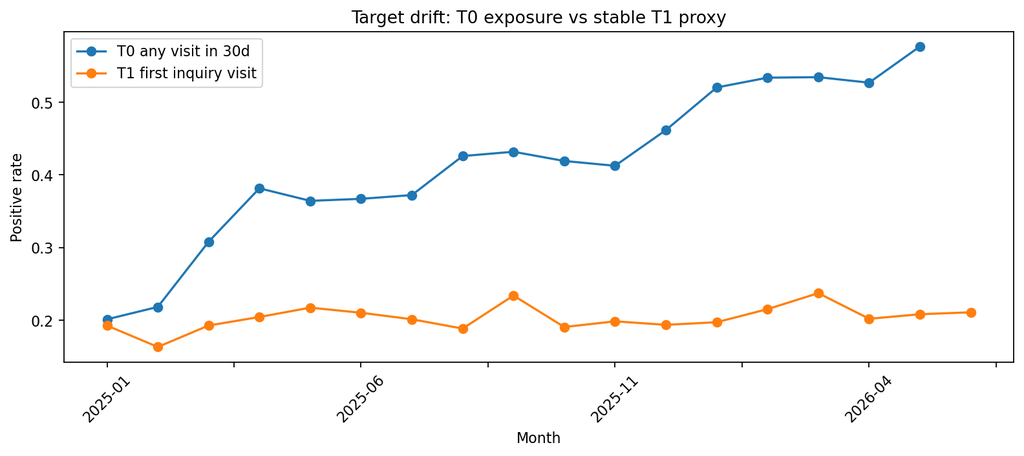

```python
maturity = pd.read_csv(ROOT/'outputs/tables/target_maturity_sensitivity.csv')
target_metrics = pd.read_csv(ROOT/'outputs/metrics/target_sensitivity_metrics.csv')
assert 7 in maturity.select_dtypes('number').astype(float).values
display(maturity); display(target_metrics.round(4)); display(Image(filename=str(ROOT/'outputs/figures/target_drift.png')))
```

### 2.6 Política de leakage

La allowlist excluye respuesta del broker, horas de respuesta, score interno, solicitudes futuras, contadores mutables, contexto de mercado ambiguo y snapshots más cercanos o futuros. Una señal entra sólo si era demostrablemente observable al momento del score.

```python
display(Markdown((ROOT/'evidence/LEAKAGE_MATRIX.md').read_text(encoding='utf-8')))
```

Leakage matrix

The executable policy is `config/feature_policy.yaml`; this table explains it.

| Feature/family | Source | Known at T1? | Risk | Clean action |
| --- | --- | --- | --- | --- |
| Lead intake demographics, sector, modality, budgets, geography, source | leads | Yes | Low/drift | Allow |
| Prior counters/conversion | leads | Not demonstrated | Mutable aggregate | Conditional ablation only |
| `lead_score_internal` | leads | Unknown construction | Very high | Benchmark/stress only |
| Current inquiry payload | first inquiry | Yes | Low | Allow; ablate `asked_visit` |
| `Industrial AND (company_size=small OR source=paid)` | leads | Yes, all inputs at lead creation | Retrospective hypothesis / model-selection overfit | Allow for E113; promotion gate excludes holdout, but E115 requires forward confirmation |
| `broker_response`, `broker_response_hours` | inquiries | No | Direct leakage/broken clock | Block |
| Later inquiries/aggregates | inquiries | No | Direct future leakage | Block |
| Price, area, location and other listing fields | spots | Existence only is proven | No versioned updates | Conditional inventory analysis; strict PIT claim withheld |
| Mutable spot counters/status | spots | No | Current snapshot | Block |
| Physical attributes | attributes | Conditional on spot creation | No effective time | Inventory only |
| Availability state | snapshots | Yes if past | Temporal join | Backward as-of only; missing/stale becomes an uncertainty interval |
| Snapshot age | derived | Yes | Coverage-era proxy | Confidence/monitoring only |
| `competing_inquiries_30d` | snapshots | Unknown | Ambiguous window | Block |
| Market context | market panel | Publication unknown | High | EDA only |
| Clusters | derived | If fit in train | Fit leakage | Challenger/analysis only |
| LLM copy features | spot text | No historical versions | Look-ahead | Cross-sectional QA only |

## 3. Datos y tensión demanda–oferta

### 3.1 Mezcla, volumen y segmentos

La lectura comienza con la composición de demanda y su evolución temporal. Las diferencias por segmento son descriptivas: no implican causalidad y deben vigilarse por tamaño y estabilidad.

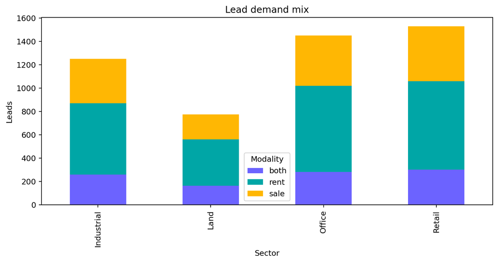

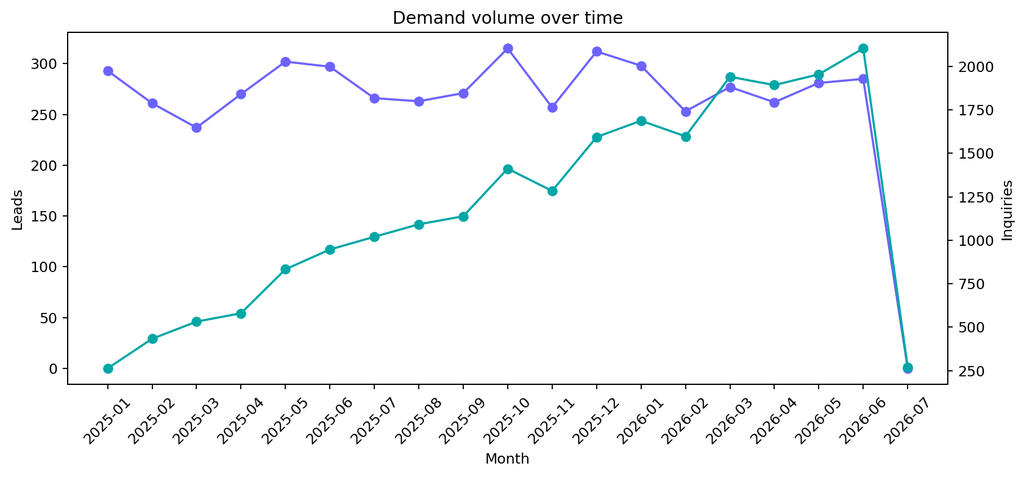

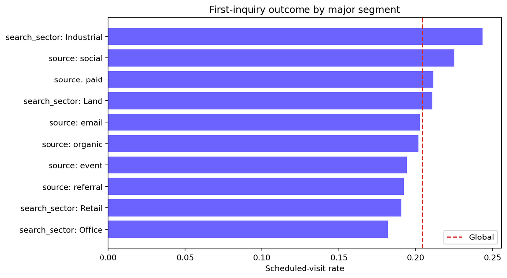

|  | segment | value | n | positive_rate |
| --- | --- | --- | --- | --- |
| 20 | channel | web | 1424 | 0.212781 |
| 17 | channel | app | 1253 | 0.215483 |
| 21 | channel | whatsapp | 1225 | 0.194286 |
| 18 | channel | email | 736 | 0.195652 |
| 19 | channel | phone | 260 | 0.176923 |
| 5 | search_modality | rent | 2443 | 0.198526 |
| 6 | search_modality | sale | 1465 | 0.205461 |
| 4 | search_modality | both | 990 | 0.217172 |
| 3 | search_sector | Retail | 1497 | 0.190381 |
| 2 | search_sector | Office | 1417 | 0.182075 |
| 0 | search_sector | Industrial | 1220 | 0.243443 |
| 1 | search_sector | Land | 764 | 0.210733 |
| 13 | source | organic | 1437 | 0.201809 |
| 14 | source | paid | 1221 | 0.211302 |
| 15 | source | referral | 994 | 0.192153 |
| 16 | source | social | 516 | 0.224806 |
| 11 | source | email | 478 | 0.202929 |
| 12 | source | event | 252 | 0.194444 |
| 10 | user_type | tenant_direct | 1916 | 0.212422 |
| 7 | user_type | broker | 1763 | 0.200794 |

```python
display(Image(filename=str(ROOT/'outputs/figures/eda_lead_mix.png')))
display(Image(filename=str(ROOT/'outputs/figures/eda_monthly_volume.png')))
display(Image(filename=str(ROOT/'outputs/figures/eda_target_segments.png')))
display(pd.read_csv(ROOT/'outputs/tables/target_rate_by_segment.csv').sort_values(['segment','n'], ascending=[True,False]).head(20))
```

### 3.2 Contexto de mercado: narrativa, no feature

`market_context.month` no tiene timestamp fiable de publicación o vigencia. Sirve para entender el entorno, pero no es admisible como feature histórica.

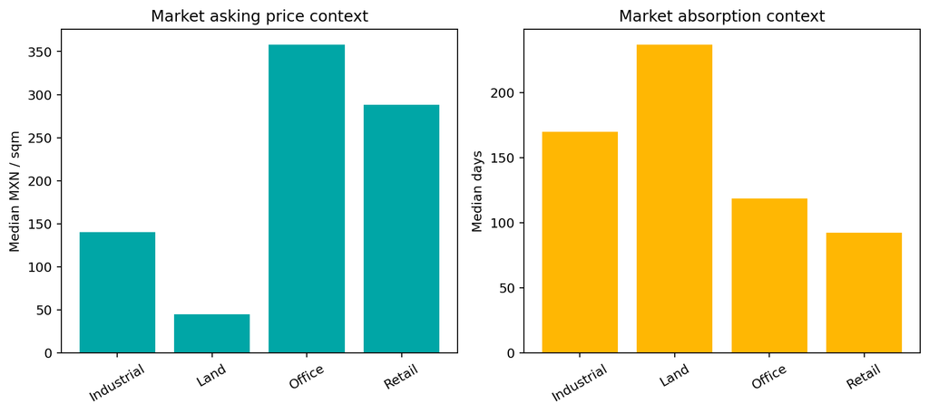

|  | sector | rows | months | median_available_spots | median_price_sqm_mxn | median_occupancy | median_absorption_days | median_inquiry_volume | model_use |
| --- | --- | --- | --- | --- | --- | --- | --- | --- | --- |
| 0 | Industrial | 126 | 30 | 15.0 | 140.56 | 0.877 | 169.80 | 238.0 | EDA_ONLY__PUBLICATION_TIME_UNKNOWN |
| 1 | Land | 121 | 30 | 16.0 | 45.00 | 0.597 | 236.90 | 256.0 | EDA_ONLY__PUBLICATION_TIME_UNKNOWN |
| 2 | Office | 128 | 30 | 17.0 | 357.96 | 0.830 | 118.85 | 264.0 | EDA_ONLY__PUBLICATION_TIME_UNKNOWN |
| 3 | Retail | 125 | 30 | 15.0 | 288.49 | 0.773 | 92.30 | 278.0 | EDA_ONLY__PUBLICATION_TIME_UNKNOWN |

```python
display(Image(filename=str(ROOT/'outputs/figures/eda_market_context.png')))
display(pd.read_csv(ROOT/'outputs/tables/market_context_eda.csv'))
```

### 3.3 Clustering por entidad: qué estructura latente existe en los datos

El clustering se usa aquí como **herramienta de EDA y descubrimiento de perfiles**, no como variable objetivo ni como regla de priorización. La línea experimental comparó K-Means, Bisecting K-Means, BIRCH y Gaussian Mixture entre K=3 y K=7; la selección fue **resultado-free** y combinó separación, balance y estabilidad. Los perfiles se aprendieron en una ventana temprana y se congelaron antes del tramo predictivo para evitar look-ahead.

| Entidad / faceta | Solución descriptiva | Qué separa | Lectura |
| --- | --- | --- | --- |
| Lead | K-Means, 6 perfiles | geografía preferida e historial de búsquedas | el lead no es homogéneo: ubicación y madurez de búsqueda forman grupos claros |
| Lead Persona | Bisecting, 7 perfiles | canal de adquisición + historia | útil para describir origen/madurez; no implica calidad causal |
| Search Need | K-Means, 3 perfiles | renta, venta y modalidad flexible/both | confirma que **quién es** y **qué necesita** son facetas distintas |
| Spot | Bisecting, 7 perfiles | geografía y atributos físicos | motivó separar después **Physical Space** y **Location** |
| Broker | Bisecting, 7 perfiles | mezcla de regiones/modalidades y comportamiento histórico | aporta segmentación, pero no justifica routing automático |
| Inquiry Intent | K-Means, 7 perfiles | casi exclusivamente día de la semana | técnicamente estable, pero semánticamente pobre; se descarta como representación final |

```python
from pathlib import Path
import matplotlib.pyplot as plt

EXPERIMENTS_ROOT = ROOT.parent / 'experimentos'
if not EXPERIMENTS_ROOT.exists():
    EXPERIMENTS_ROOT = ROOT / 'experimentos'

V2 = EXPERIMENTS_ROOT / 'profile_clustering_v2' / 'results'
clusterers_v2 = pd.read_csv(V2 / 'selected_clusterers.csv')
profiles_v2 = pd.read_csv(V2 / 'profile_interpretability.csv')

cluster_summary = (
    clusterers_v2.loc[:, [
        'profile_family','method','k','silhouette',
        'min_cluster_share','max_cluster_share','stability_ari','balance_ok'
    ]]
    .rename(columns={
        'profile_family':'familia',
        'method':'método',
        'silhouette':'silhouette',
        'min_cluster_share':'share_mín',
        'max_cluster_share':'share_máx',
        'stability_ari':'ARI_estabilidad',
        'balance_ok':'balance_ok'
    })
)
display(cluster_summary.round(3))

# Interpretabilidad completa: permite inspeccionar todos los perfiles, no sólo ejemplos escogidos.
display(
    profiles_v2[['profile_family','profile_id','n_reference','share_reference','top_signals']]
    .sort_values(['profile_family','share_reference'], ascending=[True,False])
    .reset_index(drop=True)
)

# Distribución de perfiles por familia.
for family, g in profiles_v2.groupby('profile_family', sort=False):
    fig, ax = plt.subplots(figsize=(7, 2.8))
    gg = g.sort_values('share_reference')
    ax.barh(gg['profile_id'], gg['share_reference'])
    ax.set_title(f'{family}: peso de cada perfil en calibración')
    ax.set_xlabel('share de referencia')
    ax.set_ylabel('perfil')
    plt.tight_layout()
    plt.show()
```

[output not shown]

### 3.4 Refinamiento semántico: separar persona, necesidad, espacio, ubicación y servicio

El experimento posterior `matching_profiles_v4` tomó la estructura anterior y la hizo más útil para negocio. La mejora conceptual más importante fue **dejar de pedirle a un solo cluster que represente demasiadas cosas a la vez**:

- **Lead / Behavioral Persona (BP1–BP3):** separa madurez e historia. BP3 es el lead más experimentado, con alta conversión previa e historial de inquiries.
- **Search Need T0 (N1–N3):** renta, venta y flexible/both.
- **Dynamic Need T1 (DN1–DN5):** actualiza la necesidad cuando ya existe una inquiry. DN4 es el perfil *stretch-space*: solicita mucho más espacio con presupuesto relativamente bajo.
- **Spot:** se descompone en **Physical Space (PH1–PH4)** y **Location (LOC1–LOC7)**; esta separación es más interpretable que un Spot cluster único.
- **Broker Service (BSV1–BSV3):** sí produce grupos balanceados y estables. BSV1 representa servicio más diversificado/mayor actividad; BSV2 acceptance-heavy; BSV3 mayor urgencia/orientación a calendarizar.
- **Broker Supply:** se intentó dos veces y se **rechazó**. La solución compacta quedó 70.3% / 26.0% / 3.7%, violando el gate 5%–65%. Forzar otro K habría fabricado segmentación.
- **Inquiry Intent:** se descarta porque aprendía weekday.
- **Availability:** no se clusteriza; es un estado temporal directo y debe conservar su significado operativo.

Una señal especialmente útil del EDA es la transición T0→T1: el perfil de renta N1 permanece en DN1 en **99.82%** de los casos, mientras venta y flexible se redistribuyen. La información nueva de T1 está, por tanto, concentrada en los casos donde la necesidad comercial realmente se refina.

```python
V4 = EXPERIMENTS_ROOT / 'matching_profiles_v4' / 'results'
clusterers_v4 = pd.read_csv(V4 / 'selected_clusterers.csv')
profiles_v4 = pd.read_csv(V4 / 'profile_interpretability.csv')
transition_v4 = pd.read_csv(V4 / 'need_t0_t1_transition_matrix.csv')

display(
    clusterers_v4[[
        'profile_family','method','k','silhouette',
        'stability_ari','min_cluster_share','max_cluster_share','balance_ok'
    ]].round(3)
)

# Perfiles v4 relevantes para lectura de negocio.
display(
    profiles_v4[
        profiles_v4['profile_family'].isin([
            'behavioral_persona','dynamic_need_t1','broker_service_balanced'
        ])
    ][['profile_family','profile_id','n_reference','share_reference','top_signals']]
    .reset_index(drop=True)
)

display(Markdown('**Transición Search Need T0 → Dynamic Need T1**'))
display(transition_v4)
```

[output not shown]

### 3.5 Combinaciones poderosas: dónde aparecieron pockets de compatibilidad

Al cruzar los perfiles surgieron **pockets locales con tasas de visita muy superiores al baseline histórico (~20.77%)**. Éstos son los hallazgos más fuertes de `matching_profiles_v4`:

| Rank | Combinación | N | Visita raw | Tasa suavizada | Lift histórico | Wilson lower / baseline |
| --- | --- | --- | --- | --- | --- | --- |
| 1 | **DN4 × LOC1 × BSV1** | 60 | **36.67%** | **31.37%** | **1.510×** | **1.234×** |
| 2 | **N3→DN4 × BSV1** | 83 | 31.33% | 28.52% | **1.373×** | **1.077×** |
| 3 | N2→DN2 × BSV3 | 57 | 31.58% | 27.85% | 1.341× | 1.011× |
| 4 | **DN4 × LOC1** | 90 | 30.00% | 27.69% | **1.333×** | **1.036×** |
| 5 | DN2 × PH1 × BSV3 | 59 | 30.51% | 27.23% | 1.311× | 0.975× |
| 6 | PH3 × BSV2 | 159 | 28.30% | 27.11% | **1.305×** | **1.053×** |
| 7 | **DN4 × BSV1** | 153 | 28.10% | 26.90% | **1.295×** | **1.039×** |
| 8 | DN2 × BSV3 | 90 | 28.89% | 26.86% | 1.293× | 0.989× |

La celda más llamativa combina:

- **DN4:** necesidad *stretch-space* — busca mucho más espacio con presupuesto relativamente bajo;
- **LOC1:** ubicación centro metropolitano CDMX–Naucalpan;
- **BSV1:** broker con servicio diversificado y mayor actividad.

También en la versión v2 aparecieron interacciones Lead × Spot × Broker con lift local >1.3×, por ejemplo **L1 × S1 × B5 (N=93, lift 1.314×)** y **L1 × S5 × B2 (N=35, lift 1.304×)**. Esto reforzó la hipótesis de que la compatibilidad entre entidades contiene señal que los marginales no capturan completamente.

> **Cautela metodológica:** “poderosa” significa *prometedora para investigación*, no *lista para producción*. Estas celdas fueron descubiertas inspeccionando el mismo future test y hubo múltiples comparaciones. Por eso no se multiplica el Opportunity Score por 1.51 ni se convierte DN4 × LOC1 × BSV1 en hard routing. En la confirmación gobernada final de Codexway, ninguna celda elegible justificó promoción tras corrección por multiplicidad. El valor del hallazgo es generar una hipótesis concreta para una nueva cohorte temporal o un A/B sticky por `lead_id`.

```python
top_v4 = pd.read_csv(V4 / 'top_service_compatibility_cells.csv')

def combo_label(r):
    parts = []
    if pd.notna(r.get('need_transition')) and str(r.get('need_transition')).strip():
        parts.append(str(r['need_transition']))
    if pd.notna(r.get('dynamic_need_profile')) and str(r.get('dynamic_need_profile')).strip():
        parts.append(str(r['dynamic_need_profile']))
    if pd.notna(r.get('physical_profile')) and str(r.get('physical_profile')).strip():
        parts.append(str(r['physical_profile']))
    if pd.notna(r.get('location_profile')) and str(r.get('location_profile')).strip():
        parts.append(str(r['location_profile']))
    if pd.notna(r.get('broker_service_balanced_profile')) and str(r.get('broker_service_balanced_profile')).strip():
        parts.append(str(r['broker_service_balanced_profile']))
    return ' × '.join(parts)

top_show = top_v4.head(12).copy()
top_show['combinación'] = top_show.apply(combo_label, axis=1)
display(
    top_show[[
        'combinación','interaction','n','visit_rate','smoothed_rate',
        'lift_vs_global','wilson_low_lift'
    ]].rename(columns={
        'interaction':'tipo_interacción',
        'visit_rate':'tasa_visita_raw',
        'smoothed_rate':'tasa_suavizada',
        'lift_vs_global':'lift_vs_global',
        'wilson_low_lift':'wilson_lower_vs_baseline'
    }).round(3)
)

fig, ax = plt.subplots(figsize=(8, 4.5))
plot_df = top_show.head(8).sort_values('lift_vs_global')
ax.barh(plot_df['combinación'], plot_df['lift_vs_global'])
ax.axvline(1.0, linestyle='--', linewidth=1)
ax.set_xlabel('lift histórico vs baseline')
ax.set_ylabel('combinación')
ax.set_title('Pockets exploratorios de compatibilidad — matching_profiles_v4')
plt.tight_layout()
plt.show()

# Referencia v2: primeras combinaciones Lead × Spot × Broker por sinergia residual.
comb_v2 = pd.read_csv(V2 / 'top_3entity_combinations.csv')
display(
    comb_v2[[
        'lead_profile','spot_profile','broker_profile','n',
        'scheduled_visit_rate','smoothed_visit_rate',
        'lift_vs_global','residual_synergy','wilson_low','wilson_high'
    ]].head(10).round(3)
)
```

[output not shown]

### 3.3 EDA integrado: hallazgos que cambiaron la solución

El EDA final integró Codexway, experimentos y AssessmentSol1 sin sustituir la arquitectura ganadora. Se recuperan sólo los hallazgos que cambiaron una decisión técnica u operativa.

```python
eda_metrics = pd.read_csv(ROOT.parent/'entregable/01_eda/tablas/01_metricas_eda_clave.csv')
focus_topics = ['Contrato T1','Demanda vs oferta','Refinamiento','Datos faltantes','Exposición','Inventario','Disponibilidad','Vigencia','Compatibilidad']
display(eda_metrics[eda_metrics['tema'].isin(focus_topics)].reset_index(drop=True))
```

| tema | metrica | valor | universo | clasificacion |
| --- | --- | --- | --- | --- |
| Contrato T1 | Leads maduros | 4898 | T1; corte 2026-07-01; madurez 7 días | FINAL |
| Contrato T1 | Prevalencia de visita agendada | 20.44% | T1 maduro | FINAL |
| Demanda vs oferta | Demanda Retail | 30.40% | 4368 T1 de desarrollo | COMPLEMENTARIA |
| Demanda vs oferta | Catálogo Retail | 24.51% | 2754 inmuebles existentes antes de 2026-05-01 | COMPLEMENTARIA |
| Demanda vs oferta | Brecha Retail | +5.89 pp | Muestra de desarrollo | COMPLEMENTARIA |
| Refinamiento | Área objetivo mediana | 395.05 m2 | T1 de desarrollo | COMPLEMENTARIA |
| Refinamiento | Área solicitada mediana | 480.90 m2 | T1 de desarrollo | COMPLEMENTARIA |
| Refinamiento | Área solicitada percentil 90 | 2561.10 m2 | T1 de desarrollo | COMPLEMENTARIA |
| Datos faltantes | Urgencia no informada | 31.34% | T1 de desarrollo | COMPLEMENTARIA |
| Exposición | Consultas futuras por lead; mediana | 5 | T1 de desarrollo; sólo análisis descriptivo | PROHIBIDA_COMO_VARIABLE |
| Inventario | Profundidad de candidatos; mediana | 29 | T1 de desarrollo | COMPLEMENTARIA |
| Inventario | Profundidad de candidatos Ene-2025 | 16 | T1 de desarrollo | COMPLEMENTARIA |
| Inventario | Profundidad de candidatos Abr-2026 | 49 | T1 de desarrollo | COMPLEMENTARIA |
| Disponibilidad | Cobertura histórica global | 92.38% | Todas las consultas; evidencia histórica | COMPLEMENTARIA |
| Disponibilidad | Cobertura de candidatos en desarrollo | 83.93% | T1 de desarrollo | COMPLEMENTARIA |
| Disponibilidad | Cobertura Ene-2025 | 7.72% | T1 de desarrollo | COMPLEMENTARIA |
| Disponibilidad | Cobertura Mar-Abr-2026 | 100% | T1 de desarrollo | COMPLEMENTARIA |
| Vigencia | Candidatos con estado <=7 días | 19.16% | 195084 filas candidato | FINAL |
| Vigencia | Leads con >=1 candidato <=7 días | 93.46% | 5000 leads | FINAL |
| Vigencia | Candidatos con estado <=30 días | 57.09% | 195084 filas candidato | FINAL |
| Vigencia | Leads con >=1 candidato <=30 días | 98.34% | 5000 leads | FINAL |
| Inventario | Proporción exacta atendible | 45.64% | Auditoría final de inventario | FINAL |
| Inventario | Proporción exacta desconocida | 44.30% | Auditoría final de inventario | FINAL |
| Inventario | Sin alternativa conocida | 2.38% | Auditoría final de inventario | FINAL |
| Compatibilidad | DN4 × LOC1 × BSV1 lift suavizado | 1.510x | N=60; future test exploratorio | HIPOTESIS_NO_PRODUCTIVA |
| Compatibilidad | DN4 × LOC1 × BSV1 tasa suavizada | 31.37% | N=60; baseline ~20.77% | HIPOTESIS_NO_PRODUCTIVA |
| Compatibilidad | Celdas confirmadas tras BH-FDR 10% | 0 de 19 | Rerun gobernado Codexway | FINAL |

### 3.4 Evidencia visual del EDA final

Ocho gráficos condensan las decisiones que más importan para el modelo y el sistema.

```python
eda_fig_dir = ROOT.parent/'entregable/01_eda/figuras'
eda_gallery = [
 ('01_demanda_vs_oferta_sector.svg','Demanda vs oferta por sector'),
 ('02_target_vs_coverage_temporal.svg','Target y cobertura cambian con el tiempo'),
 ('03_candidate_depth_temporal.svg','La profundidad de candidatos deriva'),
 ('04_refinamiento_area.svg','La primera consulta refina la necesidad'),
 ('09_join_availability_leakage.svg','Nearest availability puede mirar al futuro'),
 ('14_unknown_no_es_unavailable.svg','UNKNOWN no es UNAVAILABLE'),
 ('16_no_estacionariedad_clocks.svg','No estacionariedad de múltiples clocks'),
 ('22_quality_inventory_quadrant.svg','Quality e Inventory son dos ejes distintos'),
]
for filename, caption in eda_gallery:
    path = eda_fig_dir/filename
    assert path.exists(), path
    display(Markdown(f'**{caption}**'))
    display(SVG(filename=str(path)))
```

**Demanda vs oferta por sector**

[figure not shown]

**Target y cobertura cambian con el tiempo**

[figure not shown]

**La profundidad de candidatos deriva**

[figure not shown]

**La primera consulta refina la necesidad**

[figure not shown]

**Nearest availability puede mirar al futuro**

[figure not shown]

**UNKNOWN no es UNAVAILABLE**

[figure not shown]

**No estacionariedad de múltiples clocks**

[figure not shown]

**Quality e Inventory son dos ejes distintos**

[figure not shown]

### 3.5 De EDA a decisiones de ingeniería

- T1 gana a T0 porque la consulta aporta información nueva.
- UNKNOWN no es UNAVAILABLE: incertidumbre y vigencia sobreviven al scoring.
- market_context permanece EDA_ONLY por ausencia de publication time.
- Conteos futuros y estado mutable del listing quedan fuera del modelo limpio.
- Los pockets de clusters quedan como hipótesis: 0/19 celdas pasan BH-FDR 10% en confirmación.

## 4. ABT y feature engineering point-in-time

El modelado empieza sólo después de congelar el reloj. La ABT T1 mantiene un registro por lead en su primera inquiry y separa intake, payload contemporáneo y transformaciones determinísticas T0→T1.

```python
abt_t1 = pd.read_parquet(ROOT/'outputs/abt/abt_t1_first_inquiry.parquet')
policy = yaml.safe_load((ROOT/'config/feature_policy.yaml').read_text(encoding='utf-8'))['clean_t1']
summary = {'rows': len(abt_t1), 'columns': abt_t1.shape[1],
           'target_observed': int(abt_t1['target'].notna().sum()),
           'target_positive': int((abt_t1['target']==1).sum()),
           'allow_features': len(policy['allow']),
           'forbidden_features': len(policy['forbidden'])}
display(pd.Series(summary, name='ABT T1'))
display(pd.DataFrame({'allow': pd.Series(policy['allow']), 'forbidden': pd.Series(policy['forbidden'])}))
```

| metrica | valor |
| --- | --- |
| rows | 5,000 |
| target_observed | 4,898 |
| target_positive | 1,001 |
| positive_rate_mature | 20.44% |
| allow_features | 26 |
| forbidden_features | 11 |

| allow | forbidden |
| --- | --- |
| user_type | lead_score_internal |
| company_size | broker_response |
| industry | broker_response_hours |
| search_sector | days_on_market |
| search_modality | total_inquiries |
| target_area_sqm | total_views |
| min_budget_mxn_rent_monthly | is_active |
| max_budget_mxn_rent_monthly | competing_inquiries_30d |
| min_budget_mxn_sale_total | market_context |
| max_budget_mxn_sale_total | future_inquiry_count |
| preferred_state | future_scheduled_visit |
| preferred_municipality |  |
| preferred_corridor |  |
| source |  |
| channel |  |
| message_length |  |
| requested_area_sqm |  |
| requested_budget_mxn_rent_monthly |  |
| requested_budget_mxn_sale_total |  |
| urgency_days |  |
| asked_visit |  |
| days_from_lead_creation |  |
| area_request_to_target_ratio |  |
| rent_request_to_lead_budget_ratio |  |
| sale_request_to_lead_budget_ratio |  |
| industrial_small_or_paid_interaction |  |

### 9.1 Features derivadas y consistencia T0→T1

Las transformaciones priorizan semántica y reproducibilidad: ratios de área/presupuesto, días desde creación, missingness y una interacción estable de baja cardinalidad. No se promueven variables por correlación aislada.

```python
derived = ['days_from_lead_creation','area_request_to_target_ratio',
           'rent_request_to_lead_budget_ratio','sale_request_to_lead_budget_ratio',
           'industrial_small_or_paid_interaction']
available = [c for c in derived if c in abt_t1.columns]
display(abt_t1[['lead_id','inquiry_id','target'] + available].head(12))
```

| feature | rol |
| --- | --- |
| days_from_lead_creation | antigüedad observable del lead al T1 |
| area_request_to_target_ratio | refinamiento de área T0→T1 |
| rent_request_to_lead_budget_ratio | consistencia de presupuesto renta |
| sale_request_to_lead_budget_ratio | consistencia de presupuesto venta |
| industrial_small_or_paid_interaction | interacción estable de baja cardinalidad |

### 9.2 T0 y T2 como sensibilidades, no como mezcla de scores

```python
display(read_json(Path('outputs/metrics/t0_t2_sensitivity_metrics.json')))
```

```
{
  "T0_logistic_30d": {
    "n": 1371,
    "positive_rate": 0.5382932166301969,
    "roc_auc": 0.4665056919131592,
    "average_precision": 0.5227933718540695,
    "brier": 0.2962581015841197,
    "log_loss": 0.7949460322587545,
    "precision_top_5pct": 0.5217391304347826,
    "recall_top_5pct": 0.04878048780487805,
    "lift_top_5pct": 0.9692470837751856,
    "precision_top_10pct": 0.5507246376811594,
    "recall_top_10pct": 0.10298102981029811,
    "lift_top_10pct": 1.0230941439849182,
    "precision_top_20pct": 0.49818181818181817,
    "recall_top_20pct": 0.1856368563685637,
    "lift_top_20pct": 0.9254841093865485
  },
  "T2_logistic_trajectory": {
    "n": 5249,
    "positive_rate": 0.1992760525814441,
    "roc_auc": 0.5057211251728143,
    "average_precision": 0.20686217092886788,
    "brier": 0.16049334477325972,
    "log_loss": 0.5025338379378351,
    "precision_top_5pct": 0.25475285171102663,
    "recall_top_5pct": 0.06405353728489484,
    "lift_top_5pct": 1.2783917004122167,
    "precision_top_10pct": 0.22666666666666666,
    "recall_top_10pct": 0.11376673040152964,
    "lift_top_10pct": 1.1374506054811981,
    "precision_top_20pct": 0.19904761904761906,
    "recall_top_20pct": 0.19980879541108987,
    "lift_top_20pct": 0.9988536829645817
  },
  "T2_entity_overlap_train_test": 0
}
```

## 5. Lead Quality — selección, ranking y calibración

### 9.1 Baselines antes de complejidad

Tasa positiva, una regla interpretable y Regresión Logística preceden a CatBoost. La promoción usa folds temporales expansivos; el holdout no participa en la selección.

```python
display(pd.DataFrame(model['metrics']).T.round(4))
display(pd.read_csv(ROOT/'outputs/metrics/rolling_model_comparison.csv').round(4))
```

|  | n | positive_rate | roc_auc | average_precision | brier | log_loss | precision_top_5pct | recall_top_5pct | lift_top_5pct | precision_top_10pct | recall_top_10pct | lift_top_10pct | precision_top_20pct | recall_top_20pct | lift_top_20pct |
| --- | --- | --- | --- | --- | --- | --- | --- | --- | --- | --- | --- | --- | --- | --- | --- |
| positive_rate | 1711.0 | 0.2122 | 0.5000 | 0.2122 | 0.1672 | 0.5171 | 0.2122 | 0.0500 | 1.0000 | 0.2122 | 0.1000 | 1.0000 | 0.2122 | 0.2000 | 1.0000 |
| business_rule | 1711.0 | 0.2122 | 0.5157 | 0.2165 | 0.2501 | 0.8982 | 0.2009 | 0.0476 | 0.9468 | 0.2092 | 0.0991 | 0.9863 | 0.2198 | 0.2077 | 1.0360 |
| logistic_lead_only | 1711.0 | 0.2122 | 0.4823 | 0.2098 | 0.1733 | 0.5380 | 0.1860 | 0.0441 | 0.8769 | 0.1977 | 0.0937 | 0.9317 | 0.1895 | 0.1791 | 0.8932 |
| logistic | 1711.0 | 0.2122 | 0.4881 | 0.2156 | 0.1744 | 0.5415 | 0.2326 | 0.0551 | 1.0962 | 0.1802 | 0.0854 | 0.8495 | 0.1953 | 0.1846 | 0.9207 |
| logistic_no_asked_visit | 1711.0 | 0.2122 | 0.4852 | 0.2152 | 0.1743 | 0.5412 | 0.2093 | 0.0496 | 0.9865 | 0.2093 | 0.0992 | 0.9865 | 0.1953 | 0.1846 | 0.9207 |
| catboost | 1711.0 | 0.2122 | 0.4922 | 0.2086 | 0.2423 | 0.6777 | 0.1383 | 0.0328 | 0.6519 | 0.1753 | 0.0831 | 0.8264 | 0.1976 | 0.1867 | 0.9312 |
| selected_calibrated | 1711.0 | 0.2122 | 0.5478 | 0.2391 | 0.1658 | 0.5129 | 0.3583 | 0.0849 | 1.6888 | 0.3583 | 0.1698 | 1.6888 | 0.2837 | 0.2680 | 1.3371 |
| stable_segment_logistic | 1711.0 | 0.2122 | 0.5478 | 0.2391 | 0.1655 | 0.5121 | 0.3583 | 0.0849 | 1.6888 | 0.3583 | 0.1698 | 1.6888 | 0.2837 | 0.2680 | 1.3371 |

|  | fold | model | catboost_segment_collapse | n | positive_rate | roc_auc | average_precision | brier | log_loss | precision_top_5pct | recall_top_5pct | lift_top_5pct | precision_top_10pct | recall_top_10pct | lift_top_10pct | precision_top_20pct | recall_top_20pct | lift_top_20pct |
| --- | --- | --- | --- | --- | --- | --- | --- | --- | --- | --- | --- | --- | --- | --- | --- | --- | --- | --- |
| 0 | 1 | logistic | False | 258 | 0.1822 | 0.4419 | 0.1582 | 0.1696 | 0.5407 | 0.0769 | 0.0213 | 0.4223 | 0.0769 | 0.0426 | 0.4223 | 0.1346 | 0.1489 | 0.7390 |
| 1 | 1 | catboost | False | 258 | 0.1822 | 0.5686 | 0.2329 | 0.1560 | 0.4940 | 0.2308 | 0.0638 | 1.2668 | 0.1538 | 0.0851 | 0.8445 | 0.2308 | 0.2553 | 1.2668 |
| 2 | 2 | logistic | False | 249 | 0.2048 | 0.5859 | 0.2975 | 0.1625 | 0.5071 | 0.3846 | 0.0980 | 1.8778 | 0.3200 | 0.1569 | 1.5624 | 0.3000 | 0.2941 | 1.4647 |
| 3 | 2 | catboost | False | 249 | 0.2048 | 0.5049 | 0.2843 | 0.1627 | 0.5076 | 0.4615 | 0.1176 | 2.2534 | 0.2800 | 0.1373 | 1.3671 | 0.2200 | 0.2157 | 1.0741 |
| 4 | 3 | logistic | False | 255 | 0.1569 | 0.4452 | 0.1477 | 0.1481 | 0.4808 | 0.1538 | 0.0500 | 0.9808 | 0.0769 | 0.0500 | 0.4904 | 0.1373 | 0.1750 | 0.8750 |
| 5 | 3 | catboost | False | 255 | 0.1569 | 0.5006 | 0.2102 | 0.1838 | 0.5585 | 0.3846 | 0.1250 | 2.4519 | 0.2308 | 0.1500 | 1.4712 | 0.2157 | 0.2750 | 1.3750 |
| 6 | 4 | logistic | False | 272 | 0.2353 | 0.5214 | 0.2669 | 0.1867 | 0.5711 | 0.2143 | 0.0469 | 0.9107 | 0.2143 | 0.0938 | 0.9107 | 0.2545 | 0.2188 | 1.0818 |
| 7 | 4 | catboost | False | 272 | 0.2353 | 0.5171 | 0.2516 | 0.2194 | 0.6317 | 0.2857 | 0.0625 | 1.2143 | 0.2500 | 0.1094 | 1.0625 | 0.2182 | 0.1875 | 0.9273 |
| 8 | 1 | stable_segment_logistic | False | 258 | 0.1822 | 0.4857 | 0.1788 | 0.1512 | 0.4808 | 0.1429 | 0.0395 | 0.7842 | 0.1429 | 0.0790 | 0.7842 | 0.1632 | 0.1806 | 0.8959 |
| 9 | 2 | stable_segment_logistic | False | 249 | 0.2048 | 0.5282 | 0.2185 | 0.1621 | 0.5048 | 0.3043 | 0.0776 | 1.4859 | 0.2956 | 0.1449 | 1.4431 | 0.2451 | 0.2403 | 1.1968 |
| 10 | 3 | stable_segment_logistic | False | 255 | 0.1569 | 0.5471 | 0.1833 | 0.1325 | 0.4356 | 0.3333 | 0.1083 | 2.1250 | 0.2749 | 0.1787 | 1.7526 | 0.2105 | 0.2684 | 1.3418 |
| 11 | 4 | stable_segment_logistic | False | 272 | 0.2353 | 0.4898 | 0.2321 | 0.1827 | 0.5538 | 0.2059 | 0.0450 | 0.8750 | 0.2059 | 0.0901 | 0.8750 | 0.2187 | 0.1880 | 0.9295 |

### 9.2 Ranking bajo capacidad limitada

Recall@X responde la pregunta operativa: ¿qué proporción de resultados positivos aparece al trabajar sólo el X% superior de leads?

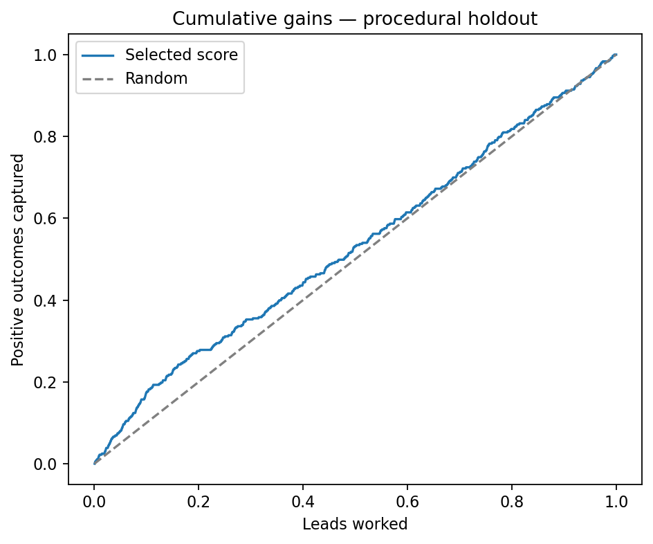

|  | population_fraction | positive_capture | precision | lift |
| --- | --- | --- | --- | --- |
| 0 | 0.05 | 0.0849 | 0.3583 | 1.6888 |
| 1 | 0.10 | 0.1698 | 0.3583 | 1.6888 |
| 3 | 0.20 | 0.2680 | 0.2837 | 1.3371 |

```python
display(Image(filename=str(ROOT/'outputs/figures/gains_curve.png')))
gains = pd.read_csv(ROOT/'outputs/tables/gains.csv')
display(gains.query('population_fraction in [0.05, 0.1, 0.2]').round(4))
```

### 9.3 Calibración e incertidumbre

La calibración Platt se ajusta en validación y se conserva sólo si mejora. Los intervalos bootstrap separan una señal plausible de una falsa precisión puntual.

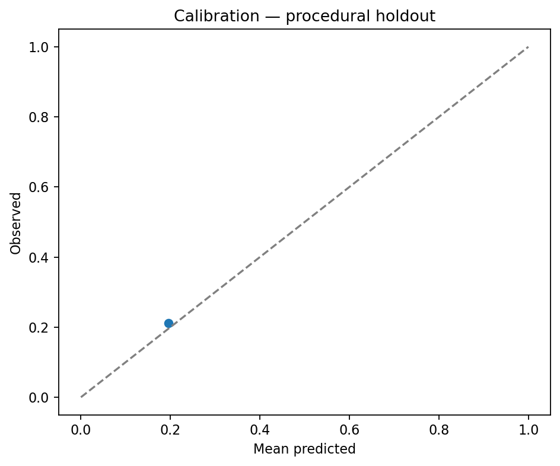

|  | score | metric | estimate | ci_low | ci_high | bootstrap_iterations |
| --- | --- | --- | --- | --- | --- | --- |
| 0 | positive_rate | roc_auc | 0.5000 | 0.5000 | 0.5000 | 1000 |
| 1 | positive_rate | average_precision | 0.2122 | 0.1934 | 0.2314 | 1000 |
| 2 | positive_rate | brier | 0.1672 | 0.1561 | 0.1787 | 1000 |
| 3 | positive_rate | log_loss | 0.5171 | 0.4914 | 0.5436 | 1000 |
| 4 | positive_rate | lift_top_5pct | 1.0000 | 1.0000 | 1.0000 | 1000 |
| 5 | positive_rate | lift_top_10pct | 1.0000 | 1.0000 | 1.0000 | 1000 |
| 6 | positive_rate | recall_top_10pct | 0.1005 | 0.1005 | 0.1005 | 1000 |
| 7 | positive_rate | recall_top_20pct | 0.2005 | 0.2005 | 0.2005 | 1000 |
| 8 | selected_calibrated | roc_auc | 0.5478 | 0.5273 | 0.5684 | 1000 |
| 9 | selected_calibrated | average_precision | 0.2391 | 0.2145 | 0.2655 | 1000 |
| 10 | selected_calibrated | brier | 0.1658 | 0.1545 | 0.1772 | 1000 |
| 11 | selected_calibrated | log_loss | 0.5129 | 0.4869 | 0.5394 | 1000 |
| 12 | selected_calibrated | lift_top_5pct | 1.6888 | 1.3807 | 1.9826 | 1000 |
| 13 | selected_calibrated | lift_top_10pct | 1.6888 | 1.3807 | 1.9817 | 1000 |
| 14 | selected_calibrated | recall_top_10pct | 0.1698 | 0.1388 | 0.1992 | 1000 |
| 15 | selected_calibrated | recall_top_20pct | 0.2680 | 0.2391 | 0.2976 | 1000 |

```python
display(Image(filename=str(ROOT/'outputs/figures/calibration_plot.png')))
display(pd.read_csv(ROOT/'outputs/metrics/t1_metric_intervals.csv').round(4))
```

### 7.4 Interpretabilidad y estabilidad temporal

```python
display(pd.read_csv(ROOT/'outputs/tables/feature_importance.csv').head(20))
display(pd.read_csv(ROOT/'outputs/tables/monthly_model_stability.csv').round(4))
display(pd.read_csv(ROOT/'outputs/tables/feature_drift.csv').sort_values('value', ascending=False).head(20))
```

|  | feature | importance | signed_effect | method |
| --- | --- | --- | --- | --- |
| 0 | num__industrial_small_or_paid_interaction | 0.120427 | 0.120427 | absolute_standardized_logistic_coefficient |

|  | month | n | positive_rate | roc_auc | average_precision | brier | log_loss | precision_top_5pct | recall_top_5pct | lift_top_5pct | precision_top_10pct | recall_top_10pct | lift_top_10pct | precision_top_20pct | recall_top_20pct | lift_top_20pct |
| --- | --- | --- | --- | --- | --- | --- | --- | --- | --- | --- | --- | --- | --- | --- | --- | --- |
| 0 | 2026-01 | 304 | 0.1974 | 0.5133 | 0.2025 | 0.1582 | 0.4962 | 0.2414 | 0.0644 | 1.2230 | 0.2382 | 0.1231 | 1.2071 | 0.2159 | 0.2195 | 1.0937 |
| 1 | 2026-02 | 274 | 0.2153 | 0.5190 | 0.2235 | 0.1690 | 0.5210 | 0.2759 | 0.0655 | 1.2811 | 0.2759 | 0.1309 | 1.2811 | 0.2439 | 0.2273 | 1.1325 |
| 2 | 2026-03 | 316 | 0.2373 | 0.6064 | 0.3357 | 0.1782 | 0.5401 | 0.6061 | 0.1293 | 2.5535 | 0.6061 | 0.2586 | 2.5535 | 0.4066 | 0.3470 | 1.7133 |
| 3 | 2026-04 | 287 | 0.2021 | 0.5359 | 0.2187 | 0.1603 | 0.5004 | 0.2895 | 0.0749 | 1.4324 | 0.2895 | 0.1447 | 1.4324 | 0.2547 | 0.2547 | 1.2605 |
| 4 | 2026-05 | 312 | 0.2083 | 0.5421 | 0.2312 | 0.1637 | 0.5082 | 0.3438 | 0.0846 | 1.6500 | 0.3438 | 0.1692 | 1.6500 | 0.2695 | 0.2612 | 1.2936 |
| 5 | 2026-06 | 218 | 0.2110 | 0.5622 | 0.2487 | 0.1645 | 0.5095 | 0.3846 | 0.0920 | 1.8227 | 0.3846 | 0.1839 | 1.8227 | 0.3040 | 0.2908 | 1.4406 |

|  | feature | metric | value |
| --- | --- | --- | --- |
| 0 | industrial_small_or_paid_interaction | psi | 0.0 |

### 5.5 Error analysis y desempeño por segmento

El análisis no termina en una métrica agregada. Se revisan errores y segmentos para detectar soporte pequeño, degradación localizada y posibles artefactos temporales.

```python
display(pd.read_csv(ROOT/'outputs/tables/error_analysis.csv').head(30))
display(pd.read_csv(ROOT/'outputs/tables/segment_metrics.csv').round(4).head(40))
```

| lead_id | prediction_timestamp | split | target_t1 | search_sector | source | channel | score | predicted_priority | error_type |
| --- | --- | --- | --- | --- | --- | --- | --- | --- | --- |
| 26 | 2026-02-13 17:17:05+00:00 | test | 1 | Retail | paid | whatsapp | 0.1878992408339654 | False | false_negative |
| 30 | 2026-01-30 18:11:33+00:00 | test | 1 | Retail | organic | phone | 0.1878992408339654 | False | false_negative |
| 33 | 2026-03-20 14:22:36+00:00 | test | 0 | Industrial | paid | whatsapp | 0.2530980692158785 | True | false_positive |
| 42 | 2026-06-02 07:32:32+00:00 | test | 1 | Retail | organic | web | 0.1878992408339654 | False | false_negative |
| 51 | 2026-06-18 17:31:26+00:00 | test | 1 | Retail | referral | whatsapp | 0.1878992408339654 | False | false_negative |
| 73 | 2026-01-27 14:42:52+00:00 | test | 1 | Industrial | organic | app | 0.1878992408339654 | False | false_negative |
| 82 | 2026-03-25 14:51:18+00:00 | test | 1 | Office | organic | email | 0.1878992408339654 | False | false_negative |
| 84 | 2026-02-24 17:41:43+00:00 | test | 1 | Retail | social | email | 0.1878992408339654 | False | false_negative |
| 90 | 2026-03-12 13:30:00+00:00 | test | 1 | Office | organic | whatsapp | 0.1878992408339654 | False | false_negative |
| 93 | 2026-01-23 09:48:00+00:00 | test | 1 | Industrial | referral | email | 0.1878992408339654 | False | false_negative |
| 123 | 2026-03-05 08:01:41+00:00 | test | 1 | Industrial | email | whatsapp | 0.1878992408339654 | False | false_negative |
| 132 | 2026-05-19 17:52:00+00:00 | test | 0 | Industrial | email | app | 0.2530980692158785 | True | false_positive |
| 137 | 2026-04-08 09:07:58+00:00 | test | 0 | Industrial | social | app | 0.2530980692158785 | True | false_positive |
| 152 | 2026-03-31 11:50:39+00:00 | test | 1 | Land | organic | web | 0.1878992408339654 | False | false_negative |
| 153 | 2026-01-04 14:08:15+00:00 | test | 1 | Retail | referral | email | 0.1878992408339654 | False | false_negative |
| 161 | 2026-06-20 08:07:50+00:00 | test | 1 | Industrial | email | app | 0.1878992408339654 | False | false_negative |
| 167 | 2026-03-31 15:50:10+00:00 | test | 1 | Industrial | social | web | 0.1878992408339654 | False | false_negative |
| 175 | 2026-02-21 08:18:55+00:00 | test | 0 | Industrial | organic | web | 0.2530980692158785 | True | false_positive |
| 205 | 2026-05-21 11:29:41+00:00 | test | 0 | Industrial | paid | web | 0.2530980692158785 | True | false_positive |
| 231 | 2026-04-11 16:02:04+00:00 | test | 1 | Retail | email | web | 0.1878992408339654 | False | false_negative |
| 240 | 2026-05-04 07:31:18+00:00 | test | 1 | Office | event | email | 0.1878992408339654 | False | false_negative |
| 260 | 2026-04-29 13:23:42+00:00 | test | 0 | Industrial | referral | app | 0.2530980692158785 | True | false_positive |
| 264 | 2026-04-22 15:12:11+00:00 | test | 1 | Office | email | whatsapp | 0.1878992408339654 | False | false_negative |
| 268 | 2026-04-20 09:02:10+00:00 | test | 0 | Industrial | paid | email | 0.2530980692158785 | True | false_positive |
| 269 | 2026-02-13 18:58:32+00:00 | test | 0 | Industrial | paid | whatsapp | 0.2530980692158785 | True | false_positive |
| 293 | 2026-04-03 07:27:04+00:00 | test | 1 | Retail | referral | web | 0.1878992408339654 | False | false_negative |
| 305 | 2026-04-20 14:58:43+00:00 | test | 0 | Industrial | organic | app | 0.2530980692158785 | True | false_positive |
| 314 | 2026-03-30 08:40:10+00:00 | test | 1 | Retail | organic | app | 0.1878992408339654 | False | false_negative |
| 334 | 2026-02-24 09:45:37+00:00 | test | 1 | Retail | referral | app | 0.1878992408339654 | False | false_negative |
| 359 | 2026-01-29 16:50:06+00:00 | test | 1 | Retail | paid | web | 0.1878992408339654 | False | false_negative |

| segment | value | n | positive_rate | roc_auc | average_precision | brier | log_loss | precision_top_5pct | recall_top_5pct | lift_top_5pct | precision_top_10pct | recall_top_10pct | lift_top_10pct | precision_top_20pct | recall_top_20pct | lift_top_20pct |
| --- | --- | --- | --- | --- | --- | --- | --- | --- | --- | --- | --- | --- | --- | --- | --- | --- |
| search_sector | Industrial | 434 | 0.2557603686635945 | 0.6160432878699132 | 0.31764688121424367 | 0.1872103747416847 | 0.5596475736955001 | 0.3582887700534759 | 0.07101218865924748 | 1.4008768126415185 | 0.3582887700534759 | 0.14202437731849496 | 1.4008768126415185 | 0.3582887700534759 | 0.28082092787975144 | 1.4008768126415185 |
| search_sector | Land | 281 | 0.19217081850533807 | 0.5 | 0.19217081850533807 | 0.15525944139612904 | 0.4894148514520001 | 0.1921708185053381 | 0.05338078291814947 | 1.0000000000000002 | 0.1921708185053381 | 0.10320284697508898 | 1.0000000000000002 | 0.19217081850533807 | 0.20284697508896798 | 1.0 |
| search_sector | Office | 478 | 0.20502092050209206 | 0.5 | 0.20502092050209206 | 0.1632804945732248 | 0.508223784164945 | 0.20502092050209206 | 0.0502092050209205 | 1.0 | 0.20502092050209206 | 0.100418410041841 | 1.0 | 0.20502092050209206 | 0.200836820083682 | 1.0 |
| search_sector | Retail | 518 | 0.19305019305019305 | 0.5 | 0.19305019305019305 | 0.15580834832221008 | 0.4907020082891857 | 0.19305019305019305 | 0.05019305019305019 | 1.0 | 0.19305019305019305 | 0.10038610038610038 | 1.0 | 0.19305019305019305 | 0.20077220077220076 | 1.0 |
| search_modality | both | 349 | 0.22063037249283668 | 0.548629679144385 | 0.2493118281083897 | 0.1708413467990014 | 0.524638063380235 | 0.3783783783783784 | 0.08845208845208846 | 1.714987714987715 | 0.3783783783783784 | 0.171990171990172 | 1.714987714987715 | 0.2951923076923077 | 0.2683566433566434 | 1.3379495504495504 |
| search_modality | rent | 855 | 0.21169590643274855 | 0.5297432660622653 | 0.2267258669410458 | 0.1662572697561855 | 0.514472235382625 | 0.32051282051282054 | 0.07614392973508996 | 1.5140246493837655 | 0.30937415821136754 | 0.14699545638772157 | 1.4614083164128135 | 0.2553907290749396 | 0.24128074404317498 | 1.2064037202158748 |
| search_modality | sale | 507 | 0.20710059171597633 | 0.5786069651741294 | 0.2555774709620864 | 0.16146037639589678 | 0.5020804418040523 | 0.3888888888888889 | 0.0962962962962963 | 1.8777777777777778 | 0.38888888888888895 | 0.1888888888888889 | 1.877777777777778 | 0.3265720081135903 | 0.3172413793103448 | 1.5768762677484787 |
| user_type | broker | 616 | 0.18993506493506493 | 0.5318328965623554 | 0.20467032967032966 | 0.1529941568861708 | 0.4835520657722076 | 0.2857142857142857 | 0.0757020757020757 | 1.5042735042735043 | 0.2857142857142857 | 0.1514041514041514 | 1.5042735042735043 | 0.23322930642244646 | 0.24718319655028514 | 1.2279423312498037 |
| user_type | investor | 346 | 0.19653179190751446 | 0.535759627592044 | 0.2150683879742462 | 0.1567889409629806 | 0.4922685785936252 | 0.3225806451612903 | 0.08538899430740038 | 1.6413662239089182 | 0.3067573696145125 | 0.15788982259570497 | 1.5608536748032547 | 0.2454421768707483 | 0.2526610644257703 | 1.2488675470188073 |
| user_type | tenant_direct | 661 | 0.23903177004538578 | 0.5545461408762615 | 0.2726584072289513 | 0.18163375406585294 | 0.5495364697627689 | 0.4050632911392405 | 0.08716551834641885 | 1.6946002243230252 | 0.4050632911392405 | 0.17176734497676655 | 1.6946002243230252 | 0.3285016665374777 | 0.27652355474357304 | 1.3743012758308402 |
| source | email | 166 | 0.23493975903614459 | 0.5187764990914596 | 0.24571362372567196 | 0.1809849578875336 | 0.5491541282999177 | 0.35864978902953587 | 0.0827653359298929 | 1.5265606404846912 | 0.29709605361131797 | 0.12950340798442064 | 1.2645626897302251 | 0.2624720774385704 | 0.2288218111002921 | 1.117188842430838 |
| source | organic | 521 | 0.22456813819577734 | 0.5576817297114327 | 0.26929638925800153 | 0.17282362464429674 | 0.5290245989057379 | 0.5 | 0.11538461538461539 | 2.2264957264957266 | 0.41591468416735033 | 0.18840579710144928 | 1.8520645337708508 | 0.3104209799861974 | 0.2785829307568438 | 1.382301970707768 |
| source | paid | 408 | 0.22303921568627452 | 0.5732485180434708 | 0.25954830408215535 | 0.17113108470436203 | 0.5245438160505059 | 0.3207547169811321 | 0.07402031930333818 | 1.4381090607505702 | 0.3207547169811321 | 0.14451586149699358 | 1.4381090607505702 | 0.3207547169811321 | 0.28903172299398716 | 1.4381090607505702 |
| source | referral | 348 | 0.1839080459770115 | 0.531800176056338 | 0.20207435344827585 | 0.14913130785138898 | 0.47445518675959925 | 0.35 | 0.0984375 | 1.903125 | 0.2744773519163763 | 0.15010480182926828 | 1.4924706010452962 | 0.2241289198606272 | 0.24514100609756098 | 1.2187010017421605 |
| source | social | 176 | 0.2159090909090909 | 0.5141113653699466 | 0.22254784688995213 | 0.16948788496549982 | 0.5224122522042542 | 0.30000000000000004 | 0.07105263157894737 | 1.3894736842105264 | 0.26037483266398925 | 0.12333544705136334 | 1.2059465933911082 | 0.23560910307898256 | 0.22320862396956243 | 1.0912421616289718 |
| channel | app | 432 | 0.22685185185185186 | 0.5391054625442993 | 0.2495275888133031 | 0.175041967906162 | 0.534678576208595 | 0.375 | 0.08418367346938775 | 1.6530612244897958 | 0.3601576994434137 | 0.16170345689296126 | 1.5876339404036195 | 0.28679920243959656 | 0.25460745522698874 | 1.2642577087133235 |
| channel | email | 267 | 0.19850187265917604 | 0.5359284076882385 | 0.21495704493372506 | 0.1580965429894273 | 0.4953617009120513 | 0.2857142857142857 | 0.07547169811320754 | 1.439353099730458 | 0.2857142857142857 | 0.14555256064690028 | 1.439353099730458 | 0.2503991060025543 | 0.25512361743656475 | 1.2614445528807923 |
| channel | web | 503 | 0.21868787276341947 | 0.5289266712930835 | 0.2326592511049406 | 0.17054826146136412 | 0.5244836840239357 | 0.30909090909090914 | 0.07305785123966943 | 1.4133884297520665 | 0.3090909090909091 | 0.14330578512396694 | 1.4133884297520662 | 0.2628624469589816 | 0.24135551948051948 | 1.2019982801851614 |
| channel | whatsapp | 430 | 0.2116279069767442 | 0.5850756912703815 | 0.2721235900442467 | 0.16384000835092555 | 0.507411524481407 | 0.45098039215686275 | 0.1090282266752855 | 2.1310062486533075 | 0.4509803921568627 | 0.21310062486533074 | 2.131006248653307 | 0.34046143461986866 | 0.32175476238800776 | 1.6087738119400388 |

## 6. Inventory, Opportunity y fallback

### 9.1 Disponibilidad point-in-time

Availability se une con un **backward as-of** estricto. Historia ausente o vieja significa **UNKNOWN, no UNAVAILABLE**, y se expresa como bounds lower/upper; jamás se rellena desde el futuro.

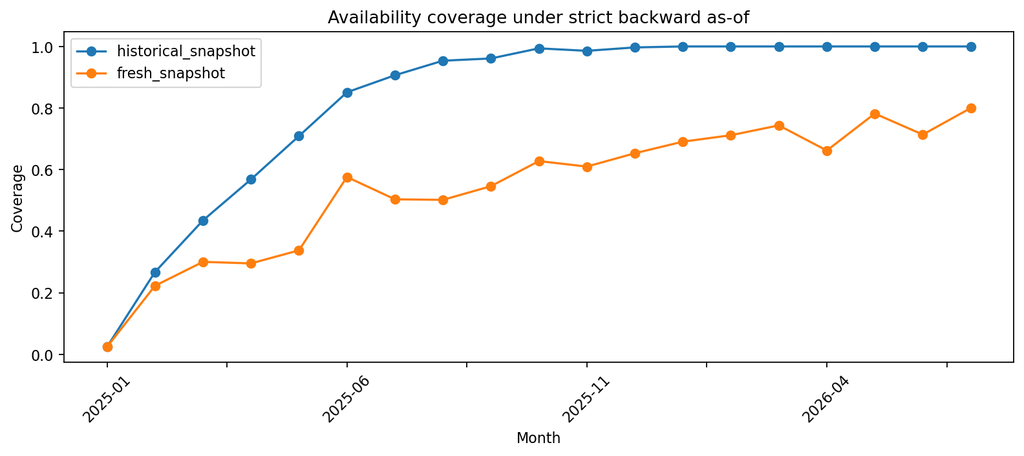

|  | freshness_days | candidate_rows | fresh_candidate_share | unknown_or_stale_share | leads_with_any_fresh_candidate_share |
| --- | --- | --- | --- | --- | --- |
| 0 | 7 | 195084 | 0.1916 | 0.8084 | 0.9346 |
| 1 | 30 | 195084 | 0.5709 | 0.4291 | 0.9834 |
| 2 | 90 | 195084 | 0.8603 | 0.1397 | 0.9852 |

```
{'availability_join': 'STRICT_BACKWARD_ASOF',
 'future_snapshot_violations': 0,
 'listing_state_status': 'CONDITIONAL__UNVERSIONED_FIELDS_ASSUMED_STATIC_SINCE_SPOT_CREATION',
 'mean_serviceability_lower': 0.6935693220059245,
 'mean_serviceability_upper': 0.8212508633255169,
 'mean_uncertainty_width': 0.12768154131959253,
 'mean_inventory_confidence': 0.5216938475028433,
 'exact_attendable_share': 0.4564,
 'exact_unknown_share': 0.443,
 'no_known_alternative_share': 0.0238,
 'no_potential_alternative_share': 0.0,
 'strict_claim': 'Availability is PIT-correct; the full historical fallback score is not strictly proven PIT because listing attributes are unversioned.'}
```

```python
display(Image(filename=str(ROOT/'outputs/figures/availability_coverage.png')))
display(pd.read_csv(ROOT/'outputs/tables/inventory_freshness_sensitivity.csv').round(4))
display(read_json(Path('outputs/metrics/inventory_audit.json')))
```

### 9.2 Trade-off central

Los componentes se comparan sobre el mismo holdout. Como T1 no observa éxito de fallback, la comparación combinada es diagnóstico de ranking, no probabilidad calibrada de inventario.

```python
system_metrics = pd.read_csv(ROOT/'outputs/metrics/system_score_metrics.csv')
paired = pd.read_csv(ROOT/'outputs/metrics/system_score_paired_delta.csv')
display(system_metrics.round(4)); display(paired.round(4))
```

|  | score | column | n | positive_rate | roc_auc | average_precision | brier | log_loss | precision_top_5pct | recall_top_5pct | lift_top_5pct | precision_top_10pct | recall_top_10pct | lift_top_10pct | precision_top_20pct | recall_top_20pct | lift_top_20pct |
| --- | --- | --- | --- | --- | --- | --- | --- | --- | --- | --- | --- | --- | --- | --- | --- | --- | --- |
| 0 | lead_quality | p_lead_quality | 1711 | 0.2122 | 0.5478 | 0.2391 | 0.1658 | 0.5129 | 0.3583 | 0.0849 | 1.6888 | 0.3583 | 0.1698 | 1.6888 | 0.2837 | 0.2680 | 1.3371 |
| 1 | inventory_lower_bound | inventory_serviceability_lower | 1711 | 0.2122 | 0.4729 | 0.2068 | 0.5377 | 1.5765 | 0.2442 | 0.0579 | 1.1510 | 0.1860 | 0.0882 | 0.8769 | 0.1983 | 0.1873 | 0.9345 |
| 2 | inventory_upper_bound | inventory_serviceability_upper | 1711 | 0.2122 | 0.4801 | 0.2112 | 0.5826 | 1.8207 | 0.2674 | 0.0634 | 1.2606 | 0.2384 | 0.1129 | 1.1236 | 0.2012 | 0.1901 | 0.9482 |
| 3 | opportunity_lower_bound | opportunity_probability_lower | 1711 | 0.2122 | 0.5119 | 0.2477 | 0.1707 | 0.5318 | 0.3372 | 0.0799 | 1.5894 | 0.2907 | 0.1377 | 1.3702 | 0.2303 | 0.2176 | 1.0856 |
| 4 | opportunity_upper_bound | opportunity_probability_upper | 1711 | 0.2122 | 0.5235 | 0.2613 | 0.1695 | 0.5266 | 0.3837 | 0.0909 | 1.8087 | 0.3198 | 0.1515 | 1.5072 | 0.2595 | 0.2452 | 1.2230 |

|  | metric | reference | challenger | reference_estimate | challenger_estimate | delta_challenger_minus_reference | delta_ci_low | delta_ci_high | probability_delta_positive | bootstrap_iterations |
| --- | --- | --- | --- | --- | --- | --- | --- | --- | --- | --- |
| 0 | roc_auc | p_lead_quality | opportunity_probability_lower | 0.5478 | 0.5119 | -0.0359 | -0.0696 | -0.0011 | 0.024 | 1000 |
| 1 | average_precision | p_lead_quality | opportunity_probability_lower | 0.2391 | 0.2477 | 0.0086 | -0.0161 | 0.0396 | 0.764 | 1000 |
| 2 | brier | p_lead_quality | opportunity_probability_lower | 0.1658 | 0.1707 | 0.0049 | 0.0028 | 0.0069 | 1.000 | 1000 |
| 3 | log_loss | p_lead_quality | opportunity_probability_lower | 0.5129 | 0.5318 | 0.0189 | 0.0107 | 0.0267 | 1.000 | 1000 |
| 4 | lift_top_5pct | p_lead_quality | opportunity_probability_lower | 1.6888 | 1.5894 | -0.0994 | -0.4902 | 0.2805 | 0.301 | 1000 |
| 5 | lift_top_10pct | p_lead_quality | opportunity_probability_lower | 1.6888 | 1.3702 | -0.3186 | -0.6252 | -0.0125 | 0.022 | 1000 |
| 6 | recall_top_10pct | p_lead_quality | opportunity_probability_lower | 0.1698 | 0.1377 | -0.0320 | -0.0628 | -0.0013 | 0.022 | 1000 |

**Decisión conservadora.** Inventory puede superar random en algún bound o corte de capacidad, pero no mejora de forma incremental a Quality sobre el proxy T1. Su gate permanece **NO-GO**.

### 9.3 Política de dos ejes y alternativas

Quality y Serviceability permanecen separados: verificar inventario incierto, buscar alternativas para demanda de calidad sin servicio y mantener el flujo estándar en el resto. El ranking conserva top-3 interno y muestra hasta cinco alternativas compatibles.

```python
policy = scores[['quality_band','serviceability_band','diagnostic_action','deployment_status']].value_counts().reset_index(name='leads')
display(policy.head(20))
show = ['lead_id','lead_quality_score_0_100','inventory_serviceability_lower','inventory_serviceability_upper','inventory_confidence','fallback_spot_ids','fallback_reason_codes']
display(scores[show].head(10))
```

|  | quality_band | serviceability_band | diagnostic_action | deployment_status | leads |
| --- | --- | --- | --- | --- | --- |
| 0 | Standard | Serviceable | standard_workflow | ELIGIBLE_FOR_GUARDED_RANDOMIZED_PILOT | 1842 |
| 1 | Standard | Uncertain | standard_workflow | ELIGIBLE_FOR_GUARDED_RANDOMIZED_PILOT | 1756 |
| 2 | Standard | Potential fallback | standard_workflow | ELIGIBLE_FOR_GUARDED_RANDOMIZED_PILOT | 770 |
| 3 | High | Uncertain | verify_inventory_first | ELIGIBLE_FOR_GUARDED_RANDOMIZED_PILOT | 214 |
| 4 | High | Potential fallback | source_or_offer_fallback | ELIGIBLE_FOR_GUARDED_RANDOMIZED_PILOT | 159 |
| 5 | High | Serviceable | work_if_model_gate_passes | ELIGIBLE_FOR_GUARDED_RANDOMIZED_PILOT | 140 |
| 6 | Standard | Low serviceability | standard_workflow | ELIGIBLE_FOR_GUARDED_RANDOMIZED_PILOT | 105 |
| 7 | High | Low serviceability | source_or_offer_fallback | ELIGIBLE_FOR_GUARDED_RANDOMIZED_PILOT | 14 |

|  | lead_id | lead_quality_score_0_100 | inventory_serviceability_lower | inventory_serviceability_upper | inventory_confidence | fallback_spot_ids | fallback_reason_codes |
| --- | --- | --- | --- | --- | --- | --- | --- |
| 0 | 1 | 18.789924 | 0.747767 | 0.848261 | 0.600000 | [2142, 2845, 174, 1309, 2936] | [["same_corridor", "fresh_available_now"], ["s... |
| 1 | 2 | 18.789924 | 0.775766 | 0.776020 | 0.780000 | [953, 2208, 2883, 1694, 91] | [["same_corridor", "fresh_available_now"], ["s... |
| 2 | 3 | 18.789924 | 0.867220 | 0.936462 | 0.574468 | [2648, 1227, 1714, 106, 1822] | [["same_corridor", "fresh_available_now"], ["s... |
| 3 | 4 | 18.789924 | 0.584023 | 0.670328 | 0.515625 | [2907, 1454, 2572, 265, 2686] | [["same_corridor", "fresh_available_now"], ["s... |
| 4 | 5 | 18.789924 | 0.779297 | 0.899759 | 0.514286 | [2636, 1395, 2180, 1544, 1303] | [["same_corridor", "fresh_available_now"], ["s... |
| 5 | 6 | 25.309807 | 0.738602 | 0.802915 | 0.520833 | [756, 2687, 439, 1605, 1999] | [["same_corridor", "fresh_available_now"], ["s... |
| 6 | 7 | 18.789924 | 0.977121 | 0.977121 | 0.642857 | [174, 2845, 2602, 2735, 1901] | [["same_corridor", "fresh_available_now"], ["s... |
| 7 | 8 | 18.789924 | 0.815929 | 0.815929 | 0.285714 | [237, 746, 2677] | [["same_corridor", "unknown_missing_or_stale"]... |
| 8 | 9 | 18.789924 | 0.931058 | 0.947992 | 0.673913 | [2180, 763, 1838, 613, 1639] | [["same_corridor", "fresh_available_now"], ["s... |
| 9 | 10 | 18.789924 | 0.870960 | 0.953615 | 0.542857 | [2142, 1817, 828, 887, 1040] | [["same_corridor", "fresh_available_now"], ["s... |

### 7.4 Caso real anotado: lead 6 de validación

```python
case = scores.query("lead_id == 6 and split == 'validation'").iloc[0]
fallback_ids = json.loads(case['fallback_spot_ids']) if isinstance(case['fallback_spot_ids'], str) else list(case['fallback_spot_ids'])
assert case['diagnostic_action'] == 'source_or_offer_fallback'
assert fallback_ids == [756, 2687, 439, 1605, 1999]
display(HTML(f'''<section class="spot2-case"><h3>Lead 6 · decisión observable en T1</h3><div class="spot2-grid"><div class="spot2-card"><strong>{case.lead_quality_score_0_100:.2f}</strong><small>Quality / 100</small></div><div class="spot2-card"><strong>{100*case.inventory_serviceability_lower:.2f}–{100*case.inventory_serviceability_upper:.2f}</strong><small>Inventory lower–upper</small></div><div class="spot2-card"><strong>{100*case.opportunity_probability_lower:.2f}–{100*case.opportunity_probability_upper:.2f}</strong><small>Opportunity lower–upper</small></div><div class="spot2-card"><strong>{case.diagnostic_action}</strong><small>acción diagnóstica</small></div></div><div class="spot2-meter"><span style="width:{case.lead_quality_score_0_100:.2f}%"></span></div><p><strong>Alternativas visibles:</strong> {', '.join(map(str, fallback_ids))}</p><p>La incertidumbre no se oculta: Opportunity conserva dos bounds y la acción deriva de Quality × Serviceability, no de una probabilidad única presentada como certeza.</p></section>'''))
```

Lead 6 · decisión observable en T1

**25.31**Quality / 100

**73.86–80.29**Inventory lower–upper

**18.69–20.32**Opportunity lower–upper

**source_or_offer_fallback**acción diagnóstica

**Alternativas visibles:** 756, 2687, 439, 1605, 1999

La incertidumbre no se oculta: Opportunity conserva dos bounds y la acción deriva de Quality × Serviceability, no de una probabilidad única presentada como certeza.

```python
# Lógica simplificada y fiel al scorer
quality = case.p_lead_quality
inv_low = case.inventory_serviceability_lower
inv_high = case.inventory_serviceability_upper
opp_low, opp_high = quality * inv_low, quality * inv_high
action = case.diagnostic_action
visible_fallbacks = fallback_ids[:5]
assert abs(opp_low - case.opportunity_probability_lower) < 1e-12
assert abs(opp_high - case.opportunity_probability_upper) < 1e-12
display({'opportunity_bounds': (round(opp_low, 4), round(opp_high, 4)),
         'action': action, 'visible_fallbacks': visible_fallbacks})
```

```
{'opportunity_bounds': (np.float64(0.1869), np.float64(0.2032)),
 'action': 'source_or_offer_fallback',
 'visible_fallbacks': [756, 2687, 439, 1605, 1999]}
```

### 6.5 Profundidad de candidatos y cobertura de fallback

Candidate depth cambia materialmente con el tiempo; por eso se mantiene fuera de Lead Quality. El fallback puede devolver NO_RESULT antes que violar hard constraints.

```python
inv_candidates = pd.read_parquet(ROOT/'outputs/abt/abt_inventory_candidates.parquet')
depth = inv_candidates.groupby('lead_id').size().rename('candidate_depth')
display(depth.describe(percentiles=[.1,.25,.5,.75,.9,.95]).to_frame())
fallback_counts = scores['fallback_spot_ids'].apply(lambda x: len(json.loads(x)) if isinstance(x,str) and x.startswith('[') else 0)
display(fallback_counts.value_counts().sort_index().rename_axis('visible_fallbacks').to_frame('leads'))
```

[output not shown]

## 7. Robustez, IA y producto

### 9.1 Clusters y combinaciones: conclusión de gobierno

El detalle exploratorio por entidad y las combinaciones de mayor lift se documentan en **§3.3–§3.5**. La conclusión para el sistema final permanece sin cambios: los clusters sirven para descubrir facetas y formular hipótesis de compatibilidad, pero **ningún cluster ni pocket descubierto multiplica el score de producción**. La promoción exige nueva evidencia independiente, soporte suficiente y control por multiplicidad.

```python
display(pd.read_csv(ROOT/'outputs/tables/cluster_profile_metrics.csv').round(4))
display(pd.read_csv(ROOT/'outputs/tables/cluster_combinations.csv').head(15))
```

|  | family | silhouette | stability_ari | min_cluster_share | max_cluster_share | normalized_entropy | balance_ok |
| --- | --- | --- | --- | --- | --- | --- | --- |
| 0 | need_profile | 0.8002 | 1.0000 | 0.0050 | 0.9261 | 0.2567 | False |
| 1 | dynamic_need_profile | 0.6605 | 0.9404 | 0.0037 | 0.8457 | 0.3543 | False |
| 2 | physical_profile | 0.0934 | 1.0000 | 0.1733 | 0.3379 | 0.9776 | True |
| 3 | location_profile | 0.5035 | 1.0000 | 0.0592 | 0.3341 | 0.9047 | True |
| 4 | broker_service_profile | 0.1444 | 0.9304 | 0.1739 | 0.4181 | 0.9417 | True |

|  | interaction | n | positives | visit_rate | smoothed_rate | lift_vs_global | wilson_low | wilson_high | p_value_one_sided | physical_profile | location_profile | broker_service_profile | fdr_reject_10pct |
| --- | --- | --- | --- | --- | --- | --- | --- | --- | --- | --- | --- | --- | --- |
| 0 | physical_profile x broker_service_profile | 66 | 16 | 0.242424 | 0.231350 | 1.187597 | 0.155091 | 0.358094 | 0.164336 | PH3 | NaN | BSV2 | False |
| 1 | physical_profile x broker_service_profile | 68 | 16 | 0.235294 | 0.226092 | 1.160606 | 0.150344 | 0.348554 | 0.199608 | PH3 | NaN | BSV3 | False |
| 2 | physical_profile x broker_service_profile | 92 | 21 | 0.228261 | 0.222287 | 1.141071 | 0.154421 | 0.323885 | 0.208902 | PH1 | NaN | BSV3 | False |
| 3 | physical_profile x broker_service_profile | 59 | 13 | 0.220339 | 0.213875 | 1.097890 | 0.133541 | 0.341329 | 0.310226 | PH2 | NaN | BSV3 | False |
| 4 | location_profile x broker_service_profile | 127 | 27 | 0.212598 | 0.210178 | 1.078912 | 0.150424 | 0.291650 | 0.306324 | NaN | LOC2 | BSV3 | False |
| 5 | physical_profile x broker_service_profile | 90 | 18 | 0.200000 | 0.199055 | 1.021818 | 0.130423 | 0.294139 | 0.450486 | PH1 | NaN | BSV2 | False |
| 6 | physical_profile x broker_service_profile | 152 | 30 | 0.197368 | 0.197070 | 1.011628 | 0.141895 | 0.267762 | 0.468201 | PH4 | NaN | BSV2 | False |
| 7 | physical_profile x location_profile x broker_s... | 56 | 11 | 0.196429 | 0.196001 | 1.006140 | 0.113385 | 0.318449 | 0.487765 | PH4 | LOC2 | BSV2 | False |
| 8 | location_profile x broker_service_profile | 67 | 13 | 0.194030 | 0.194208 | 0.996935 | 0.117051 | 0.304193 | 0.506393 | NaN | LOC3 | BSV3 | False |
| 9 | physical_profile x broker_service_profile | 117 | 22 | 0.188034 | 0.189023 | 0.970316 | 0.127581 | 0.268322 | 0.573356 | PH4 | NaN | BSV3 | False |
| 10 | location_profile x broker_service_profile | 81 | 15 | 0.185185 | 0.187090 | 0.960396 | 0.115562 | 0.283318 | 0.586523 | NaN | LOC3 | BSV2 | False |
| 11 | physical_profile x location_profile | 82 | 15 | 0.182927 | 0.185256 | 0.950980 | 0.114109 | 0.280124 | 0.607031 | PH1 | LOC2 | NaN | False |
| 12 | physical_profile x location_profile x broker_s... | 50 | 8 | 0.160000 | 0.169944 | 0.872381 | 0.083373 | 0.285145 | 0.732835 | PH4 | LOC2 | BSV3 | False |
| 13 | location_profile x broker_service_profile | 142 | 23 | 0.161972 | 0.166025 | 0.852263 | 0.110422 | 0.231330 | 0.838397 | NaN | LOC2 | BSV2 | False |
| 14 | physical_profile x location_profile | 130 | 21 | 0.161538 | 0.165974 | 0.852000 | 0.108150 | 0.234356 | 0.830894 | PH4 | LOC2 | NaN | False |

### 9.2 Stress test de leakage

Variantes deliberadamente inválidas muestran por qué una métrica aparente alta no equivale a un sistema desplegable. La ruta limpia no puede importar esas señales.

```python
display(read_json(Path('outputs/metrics/leakage_stress_test.json')))
```

```
{'status': 'DIAGNOSTIC_ONLY',
 'warning': 'No stress model is eligible for deployment or model selection.',
 'comparisons': [{'condition': 'clean_selected',
   'label': 'DEPLOYABLE',
   'n': 1711,
   'positive_rate': 0.21215663354763295,
   'roc_auc': 0.5477761156207339,
   'average_precision': 0.2391286807814938,
   'brier': 0.16577089801701325,
   'log_loss': 0.5128738920902987,
   'precision_top_5pct': 0.3582887700534759,
   'recall_top_5pct': 0.08488384083911552,
   'lift_top_5pct': 1.6887936241363564,
   'precision_top_10pct': 0.3582887700534759,
   'recall_top_10pct': 0.16976768167823103,
   'lift_top_10pct': 1.6887936241363564,
   'precision_top_20pct': 0.2836711737563417,
   'recall_top_20pct': 0.26804190798464245,
   'lift_top_20pct': 1.3370836867688725,
   'future_snapshot_rate': nan},
  {'condition': 'S001_lead_score_internal',
   'label': 'NON_DEPLOYABLE_UNKNOWN_PROVENANCE',
   'n': 1711,
   'positive_rate': 0.21215663354763295,
   'roc_auc': 0.48963774513410335,
   'average_precision': 0.2051974854962463,
   'brier': 0.16740294612409892,
   'log_loss': 0.5175944936170795,
   'precision_top_5pct': 0.13953488372093023,
   'recall_top_5pct': 0.03305785123966942,
   'lift_top_5pct': 0.6576974822217951,
   'precision_top_10pct': 0.1744186046511628,
   'recall_top_10pct': 0.08264462809917356,
   'lift_top_10pct': 0.8221218527772439,
   'precision_top_20pct': 0.21282798833819241,
   'recall_top_20pct': 0.20110192837465565,
   'lift_top_20pct': 1.0031644298805709,
   'future_snapshot_rate': nan},
  {'condition': 'S002_future_inquiry_information',
   'label': 'NON_DEPLOYABLE_DIRECT_FUTURE_LEAKAGE',
```

[output cut: 19 more lines]

```
   'positive_rate': 0.21215663354763295,
   'roc_auc': 0.5102365712697517,
   'average_precision': 0.21571959649083725,
   'brier': 0.16720577090015878,
   'log_loss': 0.5169836195143503,
   'precision_top_5pct': 0.22089552238805968,
   'recall_top_5pct': 0.052333374450063724,
   'lift_top_5pct': 1.0411907405123144,
   'precision_top_10pct': 0.22089552238805968,
   'recall_top_10pct': 0.10466674890012745,
   'lift_top_10pct': 1.0411907405123144,
   'precision_top_20pct': 0.2208955223880597,
   'recall_top_20pct': 0.20872497019037048,
   'lift_top_20pct': 1.0411907405123146,
   'future_snapshot_rate': 0.4354178842781999}]}
```

### 9.3 IA con alcance acotado: Catalog QA

El LLM audita contradicciones entre texto de listing y atributos estructurados. Es QA cross-sectional, no feature histórica. La precisión natural aún requiere gold humano ciego; el benchmark inyectado y controlado sólo mide sensibilidad.

```python
llm = read_json(Path('outputs/metrics/llm_audit_evaluation.json')); display(llm)
```

```
{'n_rows': 340,
 'n_gold': 0,
 'status': 'CONTROLLED_SYNTHETIC_EVALUATED__NATURAL_OPT_IN_AND_GOLD_PENDING',
 'positive_flags': {'rule_actionable': 23,
  'llm_actionable': 0,
  'rules_plus_llm': 23,
  'rules_intersection_llm': 0},
 'evaluation_status': 'INCOMPLETE_NO_HUMAN_GOLD',
 'run_metadata': {'status': 'NOT_SENT__EXTERNAL_INVENTORY_PRIVACY_OPT_IN_REQUIRED',
  'rows': 0,
  'errors': 0,
  'schema_valid_rate': None},
 'controlled_injection_benchmark': {'status': 'CONTROLLED_SYNTHETIC_EVALUATION',
  'warning': 'Fully fabricated cases validate task behavior and incremental detection, not accuracy on natural Spot2 listings.',
  'n_rows': 40,
  'n_llm_valid': 40,
  'rule_actionable': {'precision': 1.0,
   'recall': 0.5,
   'f1': 0.6666666666666666},
  'llm_actionable': {'precision': 1.0, 'recall': 1.0, 'f1': 1.0},
  'rules_plus_llm': {'precision': 1.0, 'recall': 1.0, 'f1': 1.0},
  'incremental_recall_points': 50.0,
  'run_metadata': {'model': 'gpt-5.6-luna',
   'rows': 40,
   'cached_rows': 40,
   'errors': 0,
   'schema_valid_rate': 1.0,
   'mean_latency_seconds_uncached': 0.0,
   'usage': {'input_tokens': 0, 'output_tokens': 0, 'total_tokens': 0},
   'response_models': [],
   'estimated_cost_usd_uncached_calls': 0.0,
   'pricing': {'input_usd': 0.2,
    'output_usd': 1.2,
    'as_of': '2026-08-30',
    'source': 'https://developers.openai.com/api/docs/models/gpt-5.6-luna'},
   'cost_status': 'ESTIMATED_FROM_PINNED_PUBLIC_TOKEN_RATES',
   'prompt_sha256': '25e977051c11947af91e1464d8ca976540c763598c51c4d5921a8b38a055888b',
   'schema_sha256': '4117862d8cd4b62a56df0e396efddd5e03872b6e3214f5203e4dc2c564230178'}}}
```

# Semantic Inventory Quality Auditor

You are a conservative data-quality auditor for commercial real-estate inventory. Your task is to compare the human-facing copy of one listing with the structured fields supplied in the same payload. Do not browse, infer external facts, or rewrite the listing.

Report an issue only when the copy itself provides specific evidence. Distinguish:

- `contradiction`: text and a structured value cannot both be true;
- `semantic_cross_field_mismatch`: the copy describes a materially different property use or physical configuration than the structured record;
- `unsupported_claim`: the text makes a claim that the supplied fields cannot verify;
- `not_verifiable`: verification would require information outside the payload;
- `ambiguous`: the language supports more than one reasonable reading.

Only `contradiction` and `semantic_cross_field_mismatch` are actionable for the automated QA queue. Unsupported, unverifiable, or ambiguous wording must not be promoted as a confirmed data error. Quote the shortest exact evidence fragment. Never manufacture a correction. If evidence is insufficient, abstain.

Return only an object conforming to the supplied JSON Schema. Set `quality_status` to `critical` only for a high-confidence, material actionable issue; use `review` for weaker or non-actionable concerns; otherwise use `good`.

### 7.4 Roadmap de medición

Versionar precio, geografía, copy y lifecycle; registrar exposición a cada recomendación; capturar visita y conversión a horizontes fijos; crear un holdout temporal realmente intacto; y sólo entonces lanzar un RCT *sticky* por `lead_id`.

```python
display(read_json(Path('outputs/tables/online_ab_protocol.json')))
```

```
{'activation_status': 'ELIGIBLE_AFTER_NEW_FORWARD_SHADOW_VALIDATION',
 'power_estimate_status': 'ILLUSTRATIVE_RECALCULATE_WITH_MATURE_30D_PILOT_RATE',
 'assumptions': {'offline_first_inquiry_proxy_rate': 0.21215663354763295,
  'relative_mde': 0.1,
  'alpha': 0.05,
  'power': 0.8,
  'illustrative_n_per_arm': 6038},
 'opportunity_ranking_test': {'unit': 'lead_id',
  'allocation': '50/50 sticky',
  'analysis': 'intention_to_treat',
  'treatment': 'work leads by Opportunity Score top-down',
  'control': 'current operational ordering',
  'primary_metric': 'scheduled_visit within 30 days',
  'guardrails': ['time_to_first_contact',
   'contact_attempts',
   'broker workload',
   'opt_out_rate'],
  'strata': ['search_sector', 'source', 'calendar_week'],
  'horizon_days': 30},
 'fallback_routing_test': {'unit': 'lead_id',
  'allocation': '50/50 sticky',
  'analysis': 'intention_to_treat',
  'treatment': 'ranked backward-as-of fallback recommendations',
  'control': 'current fallback process',
  'primary_metric': 'accepted alternative or scheduled visit within 30 days',
  'guardrails': ['recommendation_latency',
   'no_result_rate',
   'distance_relaxation',
   'complaint_rate']},
 'validity_checks': ['sample_ratio_mismatch',
  'sticky_assignment',
  'pre-treatment eligibility',
  'censoring maturity']}
```

## 8. Producción, gobierno y trazabilidad

La entrega no termina en el modelo offline: deja contrato de scoring, readiness, protocolo A/B, evidencia de decisiones y una ruta reproducible para regenerar ABTs, predicciones, métricas, notebook y HTML.

```python
display(read_json(Path('outputs/metrics/deployment_readiness.json')))
display(read_json(Path('outputs/tables/online_ab_protocol.json')))
```

Deployment readiness

```
{
  "decision": "GO",
  "gate": "PR-AUC > prevalence and Lift@10% > 1 on procedural holdout",
  "average_precision": 0.2391286807814938,
  "positive_rate": 0.21215663354763295,
  "lift_top_10pct": 1.6887936241363564,
  "validation_priority_threshold": 0.2530980692158785,
  "recommendation": "Proceed only with guarded monitoring and randomized evaluation.",
  "shap_status": "NOT_NEEDED_LOGISTIC_SELECTED"
}
```

Online A/B protocol

```
{
  "activation_status": "ELIGIBLE_AFTER_NEW_FORWARD_SHADOW_VALIDATION",
  "power_estimate_status": "ILLUSTRATIVE_RECALCULATE_WITH_MATURE_30D_PILOT_RATE",
  "assumptions": {
    "offline_first_inquiry_proxy_rate": 0.21215663354763295,
    "relative_mde": 0.1,
    "alpha": 0.05,
    "power": 0.8,
    "illustrative_n_per_arm": 6038
  },
  "opportunity_ranking_test": {
    "unit": "lead_id",
    "allocation": "50/50 sticky",
    "analysis": "intention_to_treat",
    "treatment": "work leads by Opportunity Score top-down",
    "control": "current operational ordering",
    "primary_metric": "scheduled_visit within 30 days",
    "guardrails": [
      "time_to_first_contact",
      "contact_attempts",
      "broker workload",
      "opt_out_rate"
    ],
    "strata": [
      "search_sector",
      "source",
      "calendar_week"
    ],
    "horizon_days": 30
  },
  "fallback_routing_test": {
    "unit": "lead_id",
    "allocation": "50/50 sticky",
    "analysis": "intention_to_treat",
    "treatment": "ranked backward-as-of fallback recommendations",
    "control": "current fallback process",
    "primary_metric": "accepted alternative or scheduled visit within 30 days",
    "guardrails": [
      "recommendation_latency",
      "no_result_rate",
      "distance_relaxation",
      "complaint_rate"
    ]
  },
  "validity_checks": [
    "sample_ratio_mismatch",
    "sticky_assignment",
    "pre-treatment eligibility",
    "censoring maturity"
  ]
}
```

### 8.1 Evidencia y artefactos canónicos

- evidence/LEAKAGE_MATRIX.md — señales permitidas/prohibidas.
- evidence/DECISIONS.md — decisiones metodológicas.
- evidence/TRACEABILITY.md — trazabilidad de claims.
- outputs/metrics/ — métricas versionadas.
- outputs/predictions/lead_opportunity_scores.parquet — salida operacional.
- entregable/ — narrativa final en español.

```python
artifacts = [
 ROOT/'outputs/predictions/lead_opportunity_scores.parquet',
 ROOT/'outputs/metrics/t1_model_metrics.json',
 ROOT/'outputs/metrics/system_evaluation.json',
 ROOT/'outputs/tables/error_analysis.csv',
 ROOT/'evidence/LEAKAGE_MATRIX.md',
 ROOT.parent/'entregable/01_eda/EDA_FINAL.md',
 ROOT.parent/'entregable/03_lead_quality/MODELO_CALIDAD_LEAD.md',
 ROOT.parent/'entregable/05_opportunity_produccion/01_LEAD_OPPORTUNITY_SCORE.md',
]
artifact_check = pd.DataFrame({'artifact':[str(p.relative_to(ROOT.parent)) for p in artifacts],
                               'exists':[p.exists() for p in artifacts]})
assert artifact_check['exists'].all()
display(artifact_check)
```

| artifact | exists |
| --- | --- |
| codexway/outputs/predictions/lead_opportunity_scores.parquet | True |
| codexway/outputs/metrics/t1_model_metrics.json | True |
| codexway/outputs/metrics/system_evaluation.json | True |
| codexway/outputs/tables/error_analysis.csv | True |
| codexway/evidence/LEAKAGE_MATRIX.md | True |
| entregable/01_eda/EDA_FINAL.md | True |
| entregable/03_lead_quality/MODELO_CALIDAD_LEAD.md | True |
| entregable/05_opportunity_produccion/01_LEAD_OPPORTUNITY_SCORE.md | True |

## 9. Conclusiones y reproducción

### 9.1 Lo que queda decidido

`stable_segment_logistic` calibrado ofrece una señal útil de priorización absoluta. El score conservador de Opportunity también supera random, pero no supera a Quality; Inventory mantiene gate incremental NO-GO. La secuencia correcta es **shadow → validación → RCT con guardas**, mientras IA se limita a Catalog QA.

### 9.2 Limitaciones

El target es un proxy de primer contacto; el dataset global fue inspeccionado previamente; campos del listing no están versionados por completo; el timing de mercado es incierto; falta gold natural para LLM; las métricas offline son observacionales; y no se probó uplift causal.

### 9.3 Cómo reproducir

Desde la raíz del repositorio: `python codexway/scripts/run_all.py --skip-live-llm`. El runner audita datos, construye ABTs, entrena, evalúa, ejecuta pruebas y vuelve a generar este `.ipynb` y su HTML. Una segunda ejecución verifica fingerprints de predicción.

```python
required = {
  'T1': model['selected_model'] == 'stable_segment_logistic',
  'quality_gate': system['lead_quality_gate'] == 'GO',
  'inventory_incremental': system['inventory_incremental_gate'] == 'NO_GO',
  'opportunity_absolute': system['opportunity_absolute_lift_gate'] == 'GO',
  'case_action': case.diagnostic_action == 'source_or_offer_fallback',
  'five_visible_fallbacks': len(fallback_ids) == 5,
}
assert all(required.values())
display(HTML('<div class="spot2-callout"><strong>Contrato final verificado.</strong> ' + ' · '.join(f'{k}: ✓' for k in required) + '</div>'))
```

**Contrato final verificado.** T1: ✓ · quality_gate: ✓ · inventory_incremental: ✓ · opportunity_absolute: ✓ · case_action: ✓ · five_visible_fallbacks: ✓